# **Advanced Machine Learning: EasyVisa (Visa Application Processing)**

### **Context**

Business communities in the United States are facing high demand for human resources, but one of the constant challenges is identifying and attracting the right talent, which is perhaps the most important element in remaining competitive. Companies in the United States look for hard-working, talented, and qualified individuals both locally as well as abroad.

The Immigration and Nationality Act (INA) of the US permits foreign workers to come to the United States to work on either a temporary or permanent basis. The act also protects US workers against adverse impacts on their wages or working conditions by ensuring US employers' compliance with statutory requirements when they hire foreign workers to fill workforce shortages. The immigration programs are administered by the Office of Foreign Labor Certification (OFLC).

OFLC processes job certification applications for employers seeking to bring foreign workers into the United States and grants certifications in those cases where employers can demonstrate that there are not sufficient US workers available to perform the work at wages that meet or exceed the wage paid for the occupation in the area of intended employment.

### **Objective**

In FY 2016, the OFLC processed 775,979 employer applications for 1,699,957 positions for temporary and permanent labor certifications. This was a nine percent increase in the overall number of processed applications from the previous year. The process of reviewing every case is becoming a tedious task as the number of applicants is increasing every year.

The increasing number of applicants every year calls for a Machine Learning based solution that can help in shortlisting the candidates having higher chances of VISA approval. OFLC has hired the firm EasyVisa for data-driven solutions. You as a data scientist at EasyVisa have to analyze the data provided and, with the help of a classification model:

Facilitate the process of visa approvals. Recommend a suitable profile for the applicants for whom the visa should be certified or denied based on the drivers that significantly influence the case status.

### **Data Dictionary**

The data contains the different attributes of the employee and the employer. The detailed data dictionary is given below.

- **case_id** - ID of each visa application
- **continent** - Information of continent the employee
- **education_of_employee** - Information of education of the employee
- **has_job_experience** - Does the employee has any job experience? Y= Yes; N = No
- **requires_job_training** - Does the employee require any job training? Y = Yes; N = No
- **no_of_employees** - Number of employees in the employer's company
- **yr_of_estab** - Year in which the employer's company was established
- **region_of_employment** - Information of foreign worker's intended region of employment in the US.
- **prevailing_wage** - Average wage paid to similarly employed workers in a specific occupation in the area of intended employment. The purpose of the prevailing wage is to ensure that the foreign worker is not underpaid compared to other workers offering the same or similar service in the same area of employment.
- **unit_of_wage** - Unit of prevailing wage. Values include Hourly, Weekly, Monthly, and Yearly.
- **full_time_position** - Is the position of work full-time? Y = Full-Time Position; N = Part-Time Position
- **case_status** - Flag indicating if the Visa was certified or denied

### **Importing Necessary Libraries**

```python
# Libraries to help reading and manipulating the data
import pandas as pd
import numpy as np

# Libraries to help for data visualization
import matplotlib.pyplot as plt
import seaborn as sns

# Librarires to preprocess for label encoding
from sklearn.preprocessing import LabelEncoder
from sklearn.preprocessing import OneHotEncoder

# Libraries to impute missing values
from sklearn.impute import SimpleImputer
from sklearn.experimental import enable_iterative_imputer
from sklearn.impute import IterativeImputer

# Libraries to tune different models
from sklearn.model_selection import GridSearchCV
from sklearn.model_selection import RandomizedSearchCV
from sklearn.model_selection import cross_val_score
from sklearn.model_selection import train_test_split

# Libraries to build logistic regression model
from sklearn.linear_model import LogisticRegression
from sklearn.feature_selection import RFE

# Libraries to build decision tree classifier
from sklearn.tree import DecisionTreeClassifier
from sklearn.tree import plot_tree
from sklearn import tree

# Libraries for ensemble technique : bagging & boosting
from sklearn.ensemble import BaggingClassifier, RandomForestClassifier
from sklearn.ensemble import AdaBoostClassifier, GradientBoostingClassifier
from xgboost import XGBClassifier

# Libraries for performing statistical analysis
import scipy.stats as stats

# Libraries to get different metric scores
from sklearn import metrics
from sklearn.metrics import (
    f1_score,
    precision_score,
    recall_score,
    accuracy_score,
    classification_report,
    confusion_matrix,
    ConfusionMatrixDisplay,
    make_scorer
)

# Libraries for under and over sampling
from imblearn.over_sampling import SMOTE
from imblearn.under_sampling import RandomUnderSampler

# Library to suppress warnings or deprecation notes
import warnings
warnings.filterwarnings("ignore")
```

### **Importing Dataset**

```python
# uncomment and run the following lines for Google Colab
from google.colab import drive
drive.mount('/content/drive')
application_data = pd.read_csv('/content/drive/MyDrive/AI_Shared_Content/M3_W4_Project/EasyVisa.csv')

# Data Copy (to avoid changes in the orginal data)
data = application_data.copy()
```

### **Data Check and Overview**

### **Check the first and last 5 records of the dataset**

```python
# To get the first 5 records
data.head()
```

|  | case_id | continent | education_of_employee | has_job_experience | requires_job_training | no_of_employees | yr_of_estab | region_of_employment | prevailing_wage | unit_of_wage | full_time_position | case_status |
| --- | --- | --- | --- | --- | --- | --- | --- | --- | --- | --- | --- | --- |
| 0 | EZYV01 | Asia | High School | N | N | 14513 | 2007 | West | 592.2029 | Hour | Y | Denied |
| 1 | EZYV02 | Asia | Master's | Y | N | 2412 | 2002 | Northeast | 83425.6500 | Year | Y | Certified |
| 2 | EZYV03 | Asia | Bachelor's | N | Y | 44444 | 2008 | West | 122996.8600 | Year | Y | Denied |
| 3 | EZYV04 | Asia | Bachelor's | N | N | 98 | 1897 | West | 83434.0300 | Year | Y | Denied |
| 4 | EZYV05 | Africa | Master's | Y | N | 1082 | 2005 | South | 149907.3900 | Year | Y | Certified |

```python
# To get the last 5 records
data.tail()
```

|  | case_id | continent | education_of_employee | has_job_experience | requires_job_training | no_of_employees | yr_of_estab | region_of_employment | prevailing_wage | unit_of_wage | full_time_position | case_status |
| --- | --- | --- | --- | --- | --- | --- | --- | --- | --- | --- | --- | --- |
| 25475 | EZYV25476 | Asia | Bachelor's | Y | Y | 2601 | 2008 | South | 77092.57 | Year | Y | Certified |
| 25476 | EZYV25477 | Asia | High School | Y | N | 3274 | 2006 | Northeast | 279174.79 | Year | Y | Certified |
| 25477 | EZYV25478 | Asia | Master's | Y | N | 1121 | 1910 | South | 146298.85 | Year | N | Certified |
| 25478 | EZYV25479 | Asia | Master's | Y | Y | 1918 | 1887 | West | 86154.77 | Year | Y | Certified |
| 25479 | EZYV25480 | Asia | Bachelor's | Y | N | 3195 | 1960 | Midwest | 70876.91 | Year | Y | Certified |

### **Check the shape of the dataset**

```python
# Get the shape of dataset
data.shape
```

```
(25480, 12)
```

There are 25480 rows and 12 columns in the given dataset

### **Exploratory Data Analysis**

### **Check the data types of all columns in the dataset**

```python
# Get info of the dataset
data.info()
```

```
<class 'pandas.core.frame.DataFrame'>
RangeIndex: 25480 entries, 0 to 25479
Data columns (total 12 columns):
 #   Column                 Non-Null Count  Dtype
---  ------                 --------------  -----
 0   case_id                25480 non-null  object
 1   continent              25480 non-null  object
 2   education_of_employee  25480 non-null  object
 3   has_job_experience     25480 non-null  object
 4   requires_job_training  25480 non-null  object
 5   no_of_employees        25480 non-null  int64
 6   yr_of_estab            25480 non-null  int64
 7   region_of_employment   25480 non-null  object
 8   prevailing_wage        25480 non-null  float64
 9   unit_of_wage           25480 non-null  object
 10  full_time_position     25480 non-null  object
 11  case_status            25480 non-null  object
dtypes: float64(1), int64(2), object(9)
memory usage: 2.3+ MB
```

### **Observation**

- Overall, There are 12 columns in the given dataset
- 9 columns are object type (categorical type) and 3 columns are numerical.
- has_job_experience, requires_job_training, full_time_position are boolean and can be binary encoded to 1 or 0
- The categorical columns continent, region_of_employment, unit_of_wage, education_of_employees can be one-hot encoded
- company's age could be derived with respect to current year by subtracting yr_of_estab
- case_status is the target variable and should be encoded to 1 or 0 (Certified as 1, Denied as 0)
- case_id is not useful and could be dropped as it serves as identifier
- object columns can be converted to category to make the date a memory-efficient and faster for analysis and to encode
- Overall 2.3+ MB memory of data is available which is not too large

### **Check the duplicate and missing values in the dataset**

```python
# Get the duplicated values
data.duplicated().sum()
```

```
np.int64(0)
```

### **Observation**

- No duplicate values in the given *data*

### **Fixing the data types**

```python
# get the object type columns
object_columns = data.select_dtypes(['object'])
object_columns.columns
```

```
Index(['case_id', 'continent', 'education_of_employee', 'has_job_experience',
       'requires_job_training', 'region_of_employment', 'unit_of_wage',
       'full_time_position', 'case_status'],
      dtype='object')
```

```python
# change the column type to category for object type columns
for i in object_columns.columns:
  data[i] = data[i].astype('category')
```

```python
# get the data info
data.info()
```

```
<class 'pandas.core.frame.DataFrame'>
RangeIndex: 25480 entries, 0 to 25479
Data columns (total 12 columns):
 #   Column                 Non-Null Count  Dtype
---  ------                 --------------  -----
 0   case_id                25480 non-null  category
 1   continent              25480 non-null  category
 2   education_of_employee  25480 non-null  category
 3   has_job_experience     25480 non-null  category
 4   requires_job_training  25480 non-null  category
 5   no_of_employees        25480 non-null  int64
 6   yr_of_estab            25480 non-null  int64
 7   region_of_employment   25480 non-null  category
 8   prevailing_wage        25480 non-null  float64
 9   unit_of_wage           25480 non-null  category
 10  full_time_position     25480 non-null  category
 11  case_status            25480 non-null  category
dtypes: category(9), float64(1), int64(2)
memory usage: 2.0 MB
```

### **Observation**

- Memory usage got reduced from 2.3+ MB to 2.0 MB
- Memory reduction is more visible in larger datasets

### **Statistical summary of the dataset after correction**

```python
# display the statistical summary of all columns
data.describe(include='all').T
```

|  | count | unique | top | freq | mean | std | min | 25% | 50% | 75% | max |
| --- | --- | --- | --- | --- | --- | --- | --- | --- | --- | --- | --- |
| case_id | 25480 | 25480 | EZYV9999 | 1 | NaN | NaN | NaN | NaN | NaN | NaN | NaN |
| continent | 25480 | 6 | Asia | 16861 | NaN | NaN | NaN | NaN | NaN | NaN | NaN |
| education_of_employee | 25480 | 4 | Bachelor's | 10234 | NaN | NaN | NaN | NaN | NaN | NaN | NaN |
| has_job_experience | 25480 | 2 | Y | 14802 | NaN | NaN | NaN | NaN | NaN | NaN | NaN |
| requires_job_training | 25480 | 2 | N | 22525 | NaN | NaN | NaN | NaN | NaN | NaN | NaN |
| no_of_employees | 25480.0 | NaN | NaN | NaN | 5667.04321 | 22877.928848 | -26.0 | 1022.0 | 2109.0 | 3504.0 | 602069.0 |
| yr_of_estab | 25480.0 | NaN | NaN | NaN | 1979.409929 | 42.366929 | 1800.0 | 1976.0 | 1997.0 | 2005.0 | 2016.0 |
| region_of_employment | 25480 | 5 | Northeast | 7195 | NaN | NaN | NaN | NaN | NaN | NaN | NaN |
| prevailing_wage | 25480.0 | NaN | NaN | NaN | 74455.814592 | 52815.942327 | 2.1367 | 34015.48 | 70308.21 | 107735.5125 | 319210.27 |
| unit_of_wage | 25480 | 4 | Year | 22962 | NaN | NaN | NaN | NaN | NaN | NaN | NaN |
| full_time_position | 25480 | 2 | Y | 22773 | NaN | NaN | NaN | NaN | NaN | NaN | NaN |
| case_status | 25480 | 2 | Certified | 17018 | NaN | NaN | NaN | NaN | NaN | NaN | NaN |

### **Unique values of categorical columns**

```python
# Print the unique values i.e. category for continent, education_of_employee, region_of_employment and unit_of_wage columns

for category in ['continent', 'education_of_employee', 'region_of_employment', 'unit_of_wage']:
  print(f'Unique values in {category} : {data[category].value_counts()}')
  print('-'*50)
```

```
Unique values in continent : continent
Asia             16861
Europe            3732
North America     3292
South America      852
Africa             551
Oceania            192
Name: count, dtype: int64
--------------------------------------------------
Unique values in education_of_employee : education_of_employee
Bachelor's     10234
Master's        9634
High School     3420
Doctorate       2192
Name: count, dtype: int64
--------------------------------------------------
Unique values in region_of_employment : region_of_employment
Northeast    7195
South        7017
West         6586
Midwest      4307
Island        375
Name: count, dtype: int64
--------------------------------------------------
Unique values in unit_of_wage : unit_of_wage
Year     22962
Hour      2157
Week       272
Month       89
Name: count, dtype: int64
--------------------------------------------------
```

### **Observation**

- Above result confirms that 4 different units of wages, 6 continents, 5 regions applications made for 4 different eduction qualification.

### **Drop columns with all unique values**

```python
# checking for unique values in case_id column
data["case_id"].nunique()
```

```
25480
```

```python
# Above result confirms that all the values of case_id column are unique, we can drop it.
```

```python
# drop the case_id column
data.drop(["case_id"], axis=1, inplace=True)
```

```python
data.info()
```

```
<class 'pandas.core.frame.DataFrame'>
RangeIndex: 25480 entries, 0 to 25479
Data columns (total 11 columns):
 #   Column                 Non-Null Count  Dtype
---  ------                 --------------  -----
 0   continent              25480 non-null  category
 1   education_of_employee  25480 non-null  category
 2   has_job_experience     25480 non-null  category
 3   requires_job_training  25480 non-null  category
 4   no_of_employees        25480 non-null  int64
 5   yr_of_estab            25480 non-null  int64
 6   region_of_employment   25480 non-null  category
 7   prevailing_wage        25480 non-null  float64
 8   unit_of_wage           25480 non-null  category
 9   full_time_position     25480 non-null  category
 10  case_status            25480 non-null  category
dtypes: category(8), float64(1), int64(2)
memory usage: 797.7 KB
```

### **Numerical (continuous) variables and histogram**

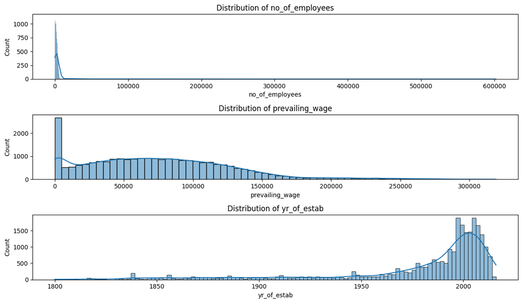

```python
# define the plot figure size
plt.figure(figsize=(12, 7))

# define the list of continuous numerical features to plot histogram to analyse the distribution and its skewness
numerical_features = ['no_of_employees', 'prevailing_wage', 'yr_of_estab']

# plot the histogram for each numerical feature
for i, feature in enumerate(numerical_features):
    plt.subplot(3, 1, i+1)
    sns.histplot(data[feature], kde=True)
    plt.title(f'Distribution of {feature}')
    plt.xlabel

plt.tight_layout()
plt.show()
```

### **Observations**

- **Employee Count Distribution** - no_of_employees exhibits strong right-skewness, reflecting a ecosystem dominated by small-to-midsize enterprises with a long right tail of massive corporate outliers.
- **Compensation Distribution** - prevailing_wage is right-skewed, with the majority of roles clustering at lower salary baselines and a high-earning tail extending into the $\$150\text{k}$–$\$300\text{k}$ range.
- **Employer Age Distribution** - yr_of_estab displays pronounced left-skewness, showing a heavy concentration of recently established firms along with a sparse tail of legacy companies founded prior to 1950 and 1850.

### **Numerical (continuous) variables and box plots**

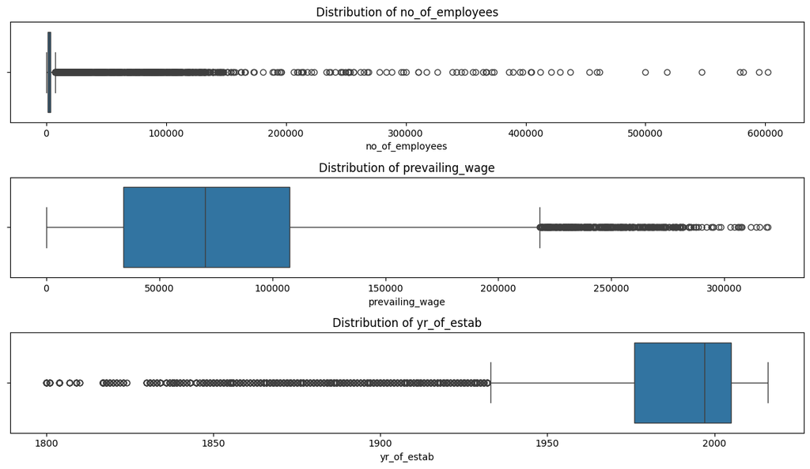

```python
# define the plot figure size
plt.figure(figsize=(12, 7))

# define the list of continuous numerical features to plot boxplot to analyse the distribution and its skewness
numerical_features = ['no_of_employees', 'prevailing_wage', 'yr_of_estab']

# plot the boxplot for each numerical feature
for i, feature in enumerate(numerical_features):
    plt.subplot(3, 1, i+1)
    sns.boxplot(x=data[feature])
    plt.title(f'Distribution of {feature}')
    plt.xlabel

plt.tight_layout()
plt.show()
```

### **Category variables and Count plots**

```
Feature: continent
continent
Asia             66.173469
Europe           14.646782
North America    12.919937
South America     3.343799
Africa            2.162480
Oceania           0.753532
Name: proportion, dtype: float64
--------------------------------------------------
Feature: education_of_employee
education_of_employee
Bachelor's     40.164835
Master's       37.810047
High School    13.422292
Doctorate       8.602826
Name: proportion, dtype: float64
--------------------------------------------------
Feature: has_job_experience
has_job_experience
Y    58.092622
N    41.907378
Name: proportion, dtype: float64
--------------------------------------------------
Feature: requires_job_training
requires_job_training
N    88.402669
Y    11.597331
Name: proportion, dtype: float64
--------------------------------------------------
Feature: region_of_employment
region_of_employment
Northeast    28.237834
South        27.539246
West         25.847724
Midwest      16.903454
Island        1.471743
Name: proportion, dtype: float64
--------------------------------------------------
Feature: unit_of_wage
unit_of_wage
Year     90.117739
Hour      8.465463
Week      1.067504
Month     0.349294
Name: proportion, dtype: float64
--------------------------------------------------
Feature: full_time_position
full_time_position
Y    89.375981
N    10.624019
Name: proportion, dtype: float64
--------------------------------------------------
Feature: case_status
case_status
Certified    66.789639
Denied       33.210361
Name: proportion, dtype: float64
--------------------------------------------------
```

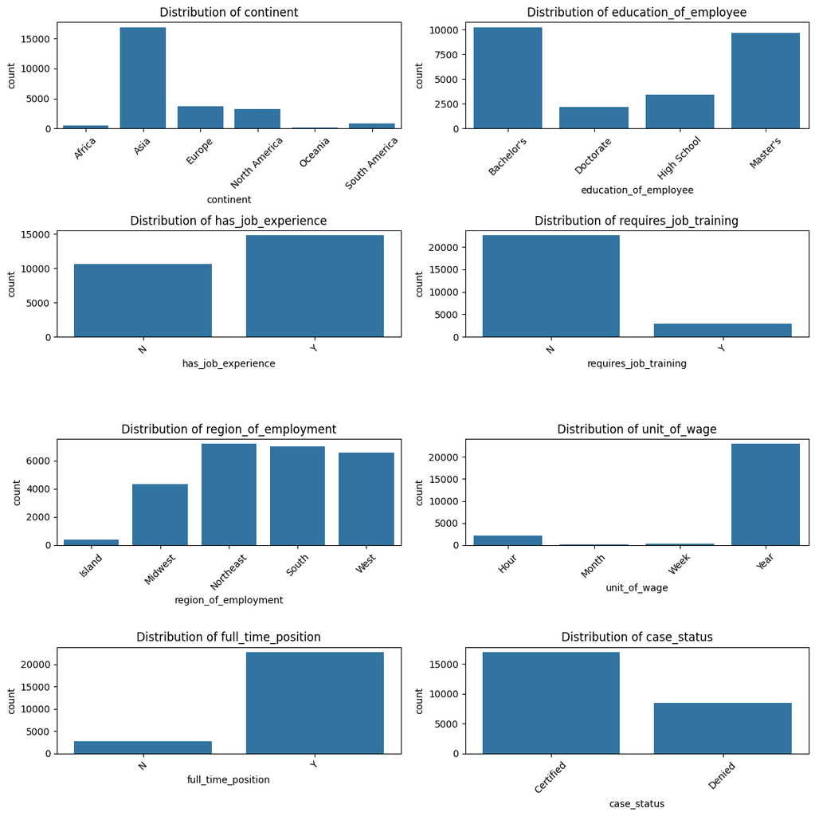

```python
# define list of categorical features to plot countplot for analysis
# List of categorical features
cat_features = ['continent', 'education_of_employee', 'has_job_experience', 'requires_job_training', 'region_of_employment', 'unit_of_wage', 'full_time_position', 'case_status']

# Print feature values in percentage
for feature in cat_features:
    percentages = 100 * data[feature].value_counts(normalize=True)
    print(f'Feature: {feature}')
    print(percentages)
    print('-'*50)

#Plot setup : 4 rows x 2 columns = 8 subplots
plt.figure(figsize=(12, 12))
total = len(data)

for i, feature in enumerate(cat_features):
    ax = plt.subplot(4, 2, i+1)
    sns.countplot(data=data, x=feature, ax=ax)
    ax.set_title(f'Countplot of {feature}')
    ax.set_title(f'Distribution of {feature}')
    ax.set_xticklabels(ax.get_xticklabels(), rotation=45)

plt.tight_layout()
plt.show()
```

### **Observations**

- **Geographic Origin** - Asian applicants dominate at $66.2\%$, followed by Europe ($14.6\%$) and North America ($12.9\%$)
- **Education Levels** - $78.0\%$ hold advanced degrees—predominantly Bachelor's ($40.2\%$) and Master's ($37.8\%$)—over Doctorate ($8.6\%$) and High School ($13.4\%$).
- **Work Experience & Training** - $58.1\%$ possess prior experience, while $88.4\%$ require no job training, pointing to a highly job-ready candidate pool.
- **Geographic Demand** - Role placements cluster heavily across three U.S. regions: Northeast ($28.2\%$), South ($27.5\%$), and West ($25.8\%$).
- **Role Permanence** - $89.4\%$ of positions are full-time, with $90.1\%$ using annual salary metrics (year), indicating long-term employment sponsorship over temporary contracts.
- **Approval Rate** - Target variable baseline yields a $66.8\%$ certification rate vs. a $33.2\%$ denial rate (approx. 2:1 ratio).

### **Numerical(continuous) variables and Heatmap correlation plot**

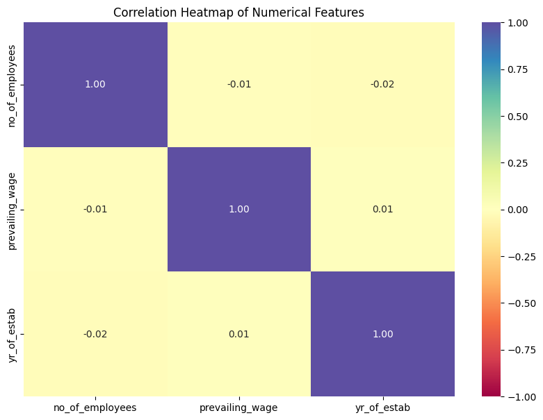

```python
num_features = ['no_of_employees', 'prevailing_wage', 'yr_of_estab']
plt.figure(figsize=(10, 7))

sns.heatmap(data[num_features].corr(),annot=True, vmin=-1, vmax=1, fmt=".2f", cmap="Spectral")
plt.title('Correlation Heatmap of Numerical Features')
plt.show()
```

### **Observations**

- Pairwise linear correlations among numerical features (no_of_employees, yr_of_estab, and prevailing_wage) are near zero, confirming no multicollinearity risks.
- **Bivariate Limitations** - Absence of linear monotonic relationships means numeric-to-numeric correlations yield no useful signals for predicting case_status, requiring non-linear evaluation or categorical grouping instead.

### **Numerical variables correlation with case status using Boxplot**

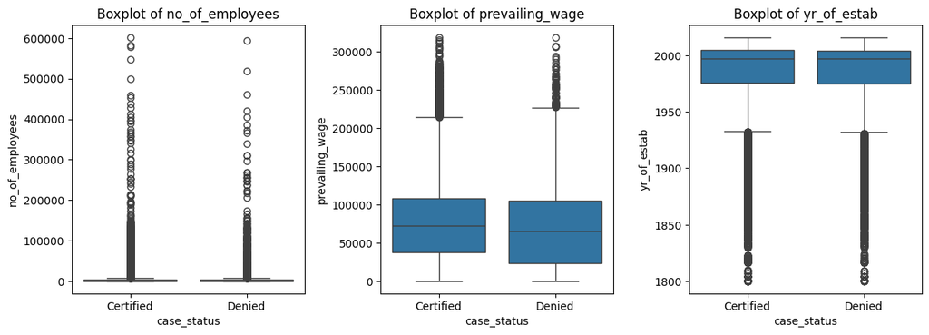

```python
# define the plot figure size
plt.figure(figsize=(12, 12))

# plot the boxplots for each numerical feature
for i, feature in enumerate(num_features):
  plt.subplot(3, 3, i+1)
  plt.title(f'Boxplot of {feature}')
  sns.boxplot(x=data['case_status'], y=data[feature])

plt.tight_layout()
plt.show()
```

### **Categorical features and target variables using Crosstab**

[figure not shown]

```python
# define list of categorical features to plot countplot for analysis
cat_features = ['continent', 'education_of_employee', 'has_job_experience', 'requires_job_training', 'region_of_employment', 'unit_of_wage', 'full_time_position', 'case_status']
plt.figure(figsize=(12, 12))


# plotting the boxplots for each numerical feature with percentage in the bars
for i, feature in enumerate(cat_features):
  plt.subplot(3,3,i+1)

  # create crosstab for case_status vs category feature
  tab = pd.crosstab(data[feature], data['case_status'], normalize='index')

  # plot within current subplt (ax passed explicitly),
  # creating a stacked bar chart from the normalized crosstab
  tab.plot(kind='bar', stacked=True, ax=plt.gca())
  plt.title(f'Crosstab of {feature} vs case_status')
  plt.xlabel(feature)
  plt.ylabel('Percentage')

  # adding a legend for the 'case_status' column
  plt.legend(title='case_status', labels=['Denied', 'Certified'])

plt.tight_layout()
plt.show()
```

### **Summary**

- **Key Discriminators** - Candidate education level and wage unit structure yield the strongest feature importance for predicting visa certification outcomes.
- **Non-Predictive Attributes** - Job training requirements and full-time employment status offer negligible signal, demonstrating virtually no influence on certification class separation.

### **Categorical features and target variables using Heatmap**

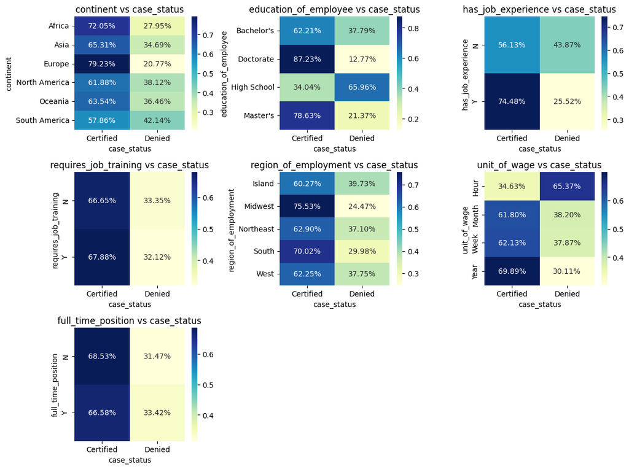

```python
# define categorical features
cat_features = ['continent', 'education_of_employee', 'has_job_experience', 'requires_job_training', 'region_of_employment', 'unit_of_wage', 'full_time_position']
plt.figure(figsize=(12, 9))

# Iterate each categorical feature and compare with outcome param case_status
for i, feature in enumerate(cat_features):
  plt.subplot(3,3,i+1)
  tab = pd.crosstab(data[feature], data['case_status'], normalize='index')

  sns.heatmap(tab, annot=True, fmt='.2%', cmap='YlGnBu')
  plt.title(f'{feature} vs case_status')
  plt.xlabel('case_status')
  plt.ylabel(feature)

plt.tight_layout()
plt.show()
```

### **Observations**

- Correlation heatmap metrics validate the bivariate crosstab observations, confirming consistent relationships between categorical attributes and case_status.

### **Data Pre-Processing and Cleanup Cont.**

### **Missing value detection and treatment**

```python
# check for missing values
data.isnull().sum()
```

|  | 0 |
| --- | --- |
| continent | 0 |
| education_of_employee | 0 |
| has_job_experience | 0 |
| requires_job_training | 0 |
| no_of_employees | 0 |
| yr_of_estab | 0 |
| region_of_employment | 0 |
| prevailing_wage | 0 |
| unit_of_wage | 0 |
| full_time_position | 0 |
| case_status | 0 |

**dtype:** int64

### **Observations**

- There are no missing values in the data

### **Duplicate value detection and treatment**

```python
# checking for duplicate values
data.duplicated().sum()
```

```
np.int64(0)
```

### **Observations**

- There are no duplicate values in the data

### **Outlier Detection and treatment**

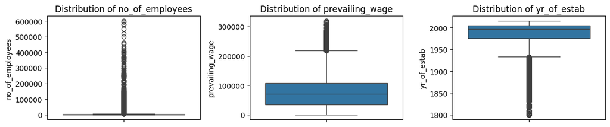

```python
# outlier detection using boxplot
plt.figure(figsize=(12, 7))

# define the list of continuous numerical features to plot boxplot to analyse the distribution and its skewness
numerical_features = ['no_of_employees', 'prevailing_wage', 'yr_of_estab']

for i, var in enumerate(numerical_features):
    plt.subplot(3, 3, i+1)
    sns.boxplot(data[var])
    plt.tight_layout()
    plt.title(f'Distribution of {var}')



plt.show()
```

### **Observations**

- **no_of_employees** - Extreme upper-tail outliers (>600k) and invalid negative entries (e.g., -26) require aggressive data cleaning, capping, or imputation prior to modeling.
- **prevailing_wage** - Significant upper-bound dispersion (>300k) reflects valid high-income roles rather than noise; standardizing values to a unified annual scale based on unit_of_wage is essential before applying transformations.
- **yr_of_estab** - Far-left tail values representing founding dates prior to **1900** act as leverage points and should be handled via floor capping or binning.

### **Negative value treatment (no_of_employees)**

```python
# get the count of no_of_employees less than zero
data[data['no_of_employees'] < 0].shape[0]
```

```
33
```

### **Observations**

- There are 33 records having negative value. They should be dropped or imputed.

```python
data[data['no_of_employees'] < 0]
```

|  | continent | education_of_employee | has_job_experience | requires_job_training | no_of_employees | yr_of_estab | region_of_employment | prevailing_wage | unit_of_wage | full_time_position | case_status |
| --- | --- | --- | --- | --- | --- | --- | --- | --- | --- | --- | --- |
| 245 | Europe | Master's | N | N | -25 | 1980 | Northeast | 39452.9900 | Year | Y | Certified |
| 378 | Asia | Bachelor's | N | Y | -11 | 2011 | Northeast | 32506.1400 | Year | Y | Denied |
| 832 | South America | Master's | Y | N | -17 | 2002 | South | 129701.9400 | Year | Y | Certified |
| 2918 | Asia | Master's | Y | N | -26 | 2005 | Midwest | 112799.4600 | Year | Y | Certified |
| 6439 | Asia | Bachelor's | N | N | -14 | 2013 | South | 103.9700 | Hour | Y | Denied |
| 6634 | Asia | Bachelor's | Y | N | -26 | 1923 | West | 5247.3200 | Year | Y | Denied |
| 7224 | Europe | Doctorate | N | N | -25 | 1998 | Midwest | 141435.9500 | Year | Y | Certified |
| 7281 | Asia | High School | N | N | -14 | 2000 | Midwest | 58488.5000 | Year | Y | Denied |
| 7318 | Asia | Bachelor's | Y | Y | -26 | 2006 | South | 115005.6100 | Year | Y | Certified |
| 7761 | Asia | Master's | N | N | -11 | 2009 | Midwest | 38457.5100 | Year | Y | Certified |
| 9872 | Europe | Master's | Y | N | -26 | 1996 | South | 37397.0500 | Year | Y | Certified |
| 11493 | Asia | High School | Y | N | -14 | 1999 | South | 27599.3500 | Year | Y | Denied |
| 13471 | North America | Master's | N | N | -17 | 2003 | Northeast | 257.2413 | Hour | Y | Denied |
| 14022 | Asia | Bachelor's | N | Y | -11 | 1946 | Northeast | 108403.5600 | Year | Y | Certified |
| 14146 | Asia | Bachelor's | N | Y | -26 | 1954 | West | 81982.2700 | Year | Y | Certified |
| 14726 | Asia | Master's | N | N | -11 | 2000 | Midwest | 167851.8000 | Year | Y | Certified |
| 15600 | Asia | Bachelor's | N | N | -14 | 2014 | South | 24641.6100 | Year | Y | Denied |
| 15859 | Asia | High School | N | N | -11 | 1969 | South | 44640.6000 | Year | Y | Denied |
| 16157 | Asia | Master's | Y | N | -11 | 1994 | South | 62681.2500 | Year | Y | Certified |
| 16883 | North America | Bachelor's | Y | N | -26 | 1968 | Northeast | 168.1558 | Hour | Y | Denied |
| 17006 | Asia | Doctorate | Y | N | -11 | 1984 | West | 25753.5100 | Year | Y | Denied |
| 17655 | North America | Bachelor's | Y | N | -17 | 2007 | Northeast | 129753.1800 | Year | Y | Denied |
| 17844 | Asia | Bachelor's | N | N | -14 | 2012 | West | 29325.8500 | Year | Y | Denied |
| 17983 | Asia | Bachelor's | N | N | -26 | 2004 | South | 84359.9800 | Year | Y | Denied |
| 20815 | Asia | Bachelor's | N | Y | -17 | 1990 | West | 91897.5700 | Year | Y | Certified |
| 20984 | Europe | Doctorate | Y | N | -14 | 1989 | Midwest | 37012.8000 | Year | Y | Certified |
| 21255 | North America | High School | N | N | -25 | 1987 | South | 99405.4700 | Year | N | Denied |
| 21760 | Asia | Bachelor's | Y | N | -25 | 2000 | West | 100463.5800 | Year | Y | Certified |
| 21944 | Africa | Master's | Y | N | -25 | 1977 | Midwest | 79150.5100 | Year | Y | Certified |
| 22084 | North America | Bachelor's | Y | N | -14 | 1980 | West | 691.0609 | Hour | Y | Denied |
| 22388 | Asia | Master's | Y | N | -14 | 1986 | South | 17893.1100 | Year | Y | Certified |
| 23186 | Asia | Master's | N | Y | -11 | 2007 | Midwest | 120195.3500 | Year | Y | Certified |
| 23476 | Europe | Master's | Y | N | -11 | 2000 | West | 95072.7500 | Year | Y | Denied |

### **Observations**

- **Data Anomaly Identification** - The negative no_of_employees entry reflects a localized data entry error rather than an invalid record, as all associated applicant attributes are valid and well-distributed.
- **Imputation Strategy** - Impute invalid employee values using the median - a robust measure of central tendency resilient to severe right-tail dispersion.
- **Data Leakage Prevention** - Compute and fit median imputations strictly on the training partition after the train-test split to prevent target and data leakage.

### **Treatment of yr_of_estab outliers**

- Rather than dropping records predating 1900 - which risks critical data loss * Transform yr_of_estab into a continuous company_age metric calculated against the dataset reference year (company_age = 2026 - yr_of_estab).
- Engineering company_age provides numerical continuity, rescales historical temporal gaps, and exposes a standardized feature representation that ML algorithms optimize more effectively.

```python
# create 'compage_age' by subtracting year of establishment from surrent year (2026)
data['company_age'] = 2026 - data['yr_of_estab']

# drop the original 'yr_of_estab' column as it is no longer needed after deriving 'company_age'
data.drop(columns='yr_of_estab', inplace=True)
```

```python
data.head()
```

|  | continent | education_of_employee | has_job_experience | requires_job_training | no_of_employees | region_of_employment | prevailing_wage | unit_of_wage | full_time_position | case_status | company_age |
| --- | --- | --- | --- | --- | --- | --- | --- | --- | --- | --- | --- |
| 0 | Asia | High School | N | N | 14513 | West | 592.2029 | Hour | Y | Denied | 19 |
| 1 | Asia | Master's | Y | N | 2412 | Northeast | 83425.6500 | Year | Y | Certified | 24 |
| 2 | Asia | Bachelor's | N | Y | 44444 | West | 122996.8600 | Year | Y | Denied | 18 |
| 3 | Asia | Bachelor's | N | N | 98 | West | 83434.0300 | Year | Y | Denied | 129 |
| 4 | Africa | Master's | Y | N | 1082 | South | 149907.3900 | Year | Y | Certified | 21 |

### **Treatment of prevailing_wage outliers**

- prevailing_wage is intrinsically tied to unit_of_wage. EDA reveals that class separation is driven primarily by the temporal unit rather than the absolute wage amount.
- The extreme dispersion in wage data (mean - 74k, std - 52k and ranges from \$2.13 to \$319,210) stems directly from mixed reporting scales. Comparing unstandardized metrics (e.g., weekly vs. annual) introduces severe scale distortion that degrades algorithm performance.
- Given the inherent lack of mathematical comparability without complex normalization and its weak standalone predictive signal - prevailing_wage will be dropped from the modeling pipeline.

```python
# describe the prevailing wage data distribution
data['prevailing_wage'].describe().T
```

|  | prevailing_wage |
| --- | --- |
| count | 25480.000000 |
| mean | 74455.814592 |
| std | 52815.942327 |
| min | 2.136700 |
| 25% | 34015.480000 |
| 50% | 70308.210000 |
| 75% | 107735.512500 |
| max | 319210.270000 |

**dtype:** float64

```python
# group prevailing wage by unit of wage to understand the data distribution
data.groupby('unit_of_wage')['prevailing_wage'].describe().sort_values(by='max', ascending=False).T
```

| unit_of_wage | Year | Week | Month | Hour |
| --- | --- | --- | --- | --- |
| count | 22962.000000 | 272.000000 | 89.000000 | 2157.000000 |
| mean | 81228.077133 | 85606.820515 | 87592.864045 | 414.570513 |
| std | 49951.473223 | 44802.704810 | 59525.124924 | 275.015000 |
| min | 100.000000 | 2183.230000 | 1599.280000 | 2.136700 |
| 25% | 43715.955000 | 51408.277500 | 44986.240000 | 152.700300 |
| 50% | 76174.500000 | 85075.820000 | 81826.010000 | 372.652300 |
| 75% | 111341.960000 | 111331.910000 | 121629.600000 | 637.311100 |
| max | 319210.270000 | 280175.950000 | 264362.950000 | 999.919500 |

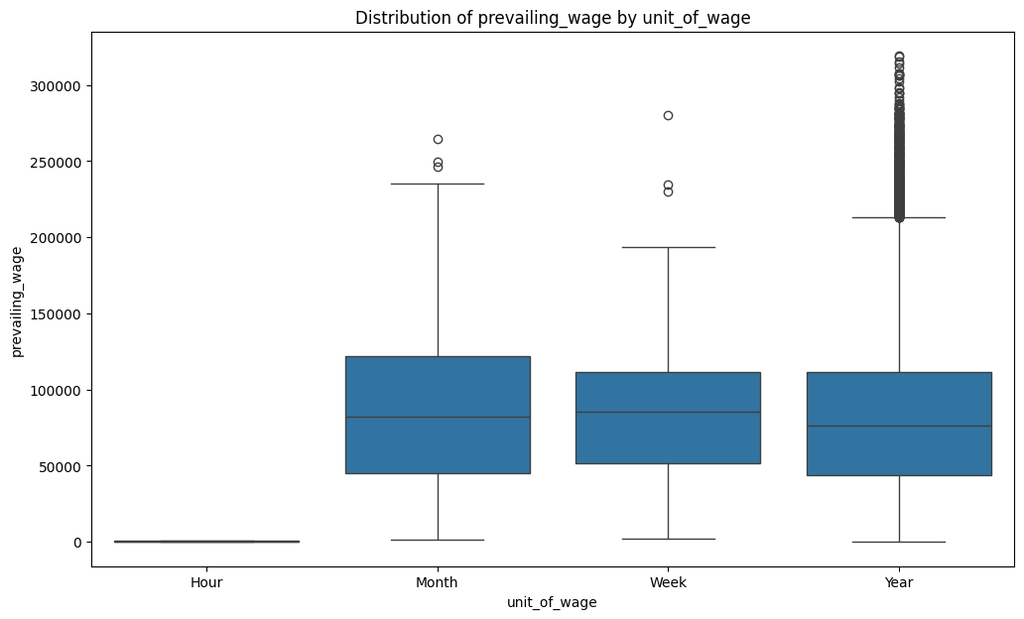

```python
# draw a boxplot to understand the wage distribution by unit of wage
plt.figure(figsize=(12, 7))
sns.boxplot(x=data['unit_of_wage'], y=data['prevailing_wage'])
plt.title('Distribution of prevailing_wage by unit_of_wage')
plt.xlabel('unit_of_wage')
plt.ylabel('prevailing_wage')
plt.show()
```

### **Observations**

- **Yearly Wages** - High variance with extensive upper outliers (>$200000) and a median lower than monthly or weekly categories.
- **Monthly & Weekly Wages** - Elevated median wage baselines compared to annual terms (skewed by lower sample sizes), with upper outliers stretching to \$250000.
- **Hourly Wages** - Compact distribution centered at the lowest overall compensation level with virtually no outliers.

### **Consideration**

- Standardizing wages across units via heuristic conversions (e.g., assuming 8-hour days, 5-day weeks, 52-week years) risks compounding extreme outlier distortion.

### **Conclusion**

- Due to structural scaling inconsistencies and potential noise amplification, prevailing_wage will be dropped from the modeling pipeline.

## **Feature Engineering**

### **Label encode categorical columns (binary/categorical target columns)**

- Following columns will be label encoded to 0 or 1
  1. as_job_experience
  2. requires_job_training
  3. full_time_position
  4. case_status

```python
# column for label encoding
label_cols = ['has_job_experience', 'requires_job_training', 'full_time_position', 'case_status']

#loop through each column and using fit_transform normalise the labels
for col in label_cols:
    le = LabelEncoder()
    data[col] = le.fit_transform(data[col])
```

```python
data.head()
```

|  | continent | education_of_employee | has_job_experience | requires_job_training | no_of_employees | region_of_employment | prevailing_wage | unit_of_wage | full_time_position | case_status | company_age |
| --- | --- | --- | --- | --- | --- | --- | --- | --- | --- | --- | --- |
| 0 | Asia | High School | 0 | 0 | 14513 | West | 592.2029 | Hour | 1 | 1 | 19 |
| 1 | Asia | Master's | 1 | 0 | 2412 | Northeast | 83425.6500 | Year | 1 | 0 | 24 |
| 2 | Asia | Bachelor's | 0 | 1 | 44444 | West | 122996.8600 | Year | 1 | 1 | 18 |
| 3 | Asia | Bachelor's | 0 | 0 | 98 | West | 83434.0300 | Year | 1 | 1 | 129 |
| 4 | Africa | Master's | 1 | 0 | 1082 | South | 149907.3900 | Year | 1 | 0 | 21 |

### **One-hot encode categorical columns (nominal)**

- Following columns will be one hot encoded
  1. continent
  2. education_of_employee
  3. regio_of_employment
  4. unit_of_wage

```python
#one hot encode columns
onehot_cols = ['continent', 'education_of_employee', 'region_of_employment', 'unit_of_wage']

#one hot encode and drop_first to avoid dummy variable trap
data = pd.get_dummies(data, columns=onehot_cols, drop_first=True)
```

```python
# verify one hot encoding
data.head()
```

|  | has_job_experience | requires_job_training | no_of_employees | prevailing_wage | full_time_position | case_status | company_age | continent_Asia | continent_Europe | continent_North America | ... | education_of_employee_Doctorate | education_of_employee_High School | education_of_employee_Master's | region_of_employment_Midwest | region_of_employment_Northeast | region_of_employment_South | region_of_employment_West | unit_of_wage_Month | unit_of_wage_Week | unit_of_wage_Year |
| --- | --- | --- | --- | --- | --- | --- | --- | --- | --- | --- | --- | --- | --- | --- | --- | --- | --- | --- | --- | --- | --- |
| 0 | 0 | 0 | 14513 | 592.2029 | 1 | 1 | 19 | True | False | False | ... | False | True | False | False | False | False | True | False | False | False |
| 1 | 1 | 0 | 2412 | 83425.6500 | 1 | 0 | 24 | True | False | False | ... | False | False | True | False | True | False | False | False | False | True |
| 2 | 0 | 1 | 44444 | 122996.8600 | 1 | 1 | 18 | True | False | False | ... | False | False | False | False | False | False | True | False | False | True |
| 3 | 0 | 0 | 98 | 83434.0300 | 1 | 1 | 129 | True | False | False | ... | False | False | False | False | False | False | True | False | False | True |
| 4 | 1 | 0 | 1082 | 149907.3900 | 1 | 0 | 21 | False | False | False | ... | False | False | True | False | False | True | False | False | False | True |

5 rows × 22 columns

```python
# display the final data info with one hot encoded columns before creation of models
data.info()
```

```
<class 'pandas.core.frame.DataFrame'>
RangeIndex: 25480 entries, 0 to 25479
Data columns (total 22 columns):
 #   Column                             Non-Null Count  Dtype
---  ------                             --------------  -----
 0   has_job_experience                 25480 non-null  int64
 1   requires_job_training              25480 non-null  int64
 2   no_of_employees                    25480 non-null  int64
 3   prevailing_wage                    25480 non-null  float64
 4   full_time_position                 25480 non-null  int64
 5   case_status                        25480 non-null  int64
 6   company_age                        25480 non-null  int64
 7   continent_Asia                     25480 non-null  bool
 8   continent_Europe                   25480 non-null  bool
 9   continent_North America            25480 non-null  bool
 10  continent_Oceania                  25480 non-null  bool
 11  continent_South America            25480 non-null  bool
 12  education_of_employee_Doctorate    25480 non-null  bool
 13  education_of_employee_High School  25480 non-null  bool
 14  education_of_employee_Master's     25480 non-null  bool
 15  region_of_employment_Midwest       25480 non-null  bool
 16  region_of_employment_Northeast     25480 non-null  bool
 17  region_of_employment_South         25480 non-null  bool
 18  region_of_employment_West          25480 non-null  bool
 19  unit_of_wage_Month                 25480 non-null  bool
 20  unit_of_wage_Week                  25480 non-null  bool
 21  unit_of_wage_Year                  25480 non-null  bool
dtypes: bool(15), float64(1), int64(6)
memory usage: 1.7 MB
```

### **Prepare data for modeling**

### Split data to train, validation, test sets

```python
# Drop 'prevailing_wage' from features and target variable 'case_status'
X = data.drop(['prevailing_wage', 'case_status'], axis=1)
y = data['case_status']
```

```python
# Data split into 2 parts : temporary and test
X_temp, X_test, y_temp, y_test = train_test_split(X, y, test_size=0.2, random_state=1, stratify=y)

# Temporary set split into train and validation
X_train, X_val, y_train, y_val = train_test_split(X_temp, y_temp, test_size=0.2, random_state=1, stratify=y_temp)

# Create table of dataset shapes with y having 1 col
shapes = pd.DataFrame({
    'Dataset': ['X_train', 'y_train', 'X_val', 'y_val', 'x_test', 'y_test'],
    'Rows': [X_train.shape[0], y_train.shape[0], X_val.shape[0], y_val.shape[0], X_test.shape[0], y_test.shape[0]],
    'Columns': [X_train.shape[1], 1, X_val.shape[1], 1, X_test.shape[1], 1]
})

print(shapes)
```

```
   Dataset   Rows  Columns
0  X_train  16307       20
1  y_train  16307        1
2    X_val   4077       20
3    y_val   4077        1
4   x_test   5096       20
5   y_test   5096        1
```

### **Verify class balance**

```python
# Create table class balance for whole data, train set, validation set and test set
class_balance = pd.DataFrame({
    'Dataset': ['y', 'y_train', 'y_val', 'y_test'],
    '0': [y.value_counts(1)[0], y_train.value_counts(1)[0], y_val.value_counts(1)[0], y_test.value_counts(1)[0]],
    '1': [y.value_counts(1)[1], y_train.value_counts(1)[1], y_val.value_counts(1)[1], y_test.value_counts(1)[1]]
})

print(class_balance)
```

```
   Dataset         0         1
0        y  0.667896  0.332104
1  y_train  0.667873  0.332127
2    y_val  0.667893  0.332107
3   y_test  0.667975  0.332025
```

### **Impute the no_of_employees**

```python
# Replace negative values with np.nan
X_train.loc[X_train['no_of_employees'] < 0, 'no_of_employees'] = np.nan
X_val.loc[X_val['no_of_employees'] < 0, 'no_of_employees'] = np.nan
X_test.loc[X_test['no_of_employees'] < 0, 'no_of_employees'] = np.nan

# Impute the missing values with SimpleImputer
imp_median = SimpleImputer(missing_values=np.nan, strategy='median')

# fit the imputer on train data and transform the train data
X_train['no_of_employees'] = imp_median.fit_transform(X_train[['no_of_employees']])

# transform the validation and test data using the imputer fit on train data
X_val['no_of_employees'] = imp_median.transform(X_val[['no_of_employees']])
X_test['no_of_employees'] = imp_median.transform(X_test[['no_of_employees']])
```

```python
# validate the count of no_of_employees less than zero to be none
print(X_train[X_train['no_of_employees'] < 0].shape[0])
print(X_val[X_val['no_of_employees'] < 0].shape[0])
print(X_test[X_test['no_of_employees'] < 0].shape[0])
```

```
0
0
0
```

## **Model Building - Original Data**

### **Model Evaluation Criterion**

#### **what does OFLC want?**

- A reliable classification model to predict VISA approval outcomes.
- Insights into key decision factors that influence approvals/denials

Reference from the problem statement : Recommend a suitable profile for the applicants for whom the visa should be certified or denied based on the drivers that significantly influence the case status.

#### **Where can the model go wrong?**

- False Positives : Predicting a Visa will be approved when it gets denied in reality could mislead employers and waste their resources.
- False Negatives : Predicting a Visa will be denied when it gets approved in reality may unfairly reject strong candidates.

#### **Which case is more important?**

**False Positives** are more important to minimize, as predicting visa appoval for candidates who ultimately get denied can:

- Mislead employers into investing time and resources in unqualified candidates.
- Undermine the credibility and efficiency of the visa processing system.
- This could also lead to challenges like non-compliance with regulations.

**False Negatives** are tolerable (but worth monitoring) as EasyVisa could reject someone who could have been approved.

### **How to reduce the losses?**

- Use robust feature engineering and ensemble models(eg: AdaBoost, GradeintBoost, XGBoost, Bagging, Random Forest).
- Apply class imbalance handling (SMOTE, Random Under Sampling, class weights).
- Use hyper parameter tuning techniques.

### **Utility Functions**

```python
# defining a function to compute different metrics to check performance of a classification model build using sklearn
def model_performance_classification(model, predictors, target):
  """
  Function to compute different metrics to check classification model performance

  model: classifier
  predictors: independent variables
  target: dependent variable
  """

  # predicting using the independent variables
  pred = model.predict(predictors)

  acc = accuracy_score(target, pred)
  recall = recall_score(target, pred)
  precision = precision_score(target, pred)
  f1 = f1_score(target, pred)

  # creating a dataframe of metrics
  df_perf = pd.DataFrame({
      'Accuracy': acc,
      'Recall': recall,
      'Precision': precision,
      'F1': f1,
      }, index=[0])

  return df_perf
```

```python
# function to create a single DataFrame of training, validation performances
def model_performances(train, validation):

  # combine the dataframes across rows
  combined = pd.concat([train, validation], axis=0, keys=["Training", "Validation"])

  # drop the index
  combined.reset_index(level=1, drop=True)
  return combined
```

```python
# function to plot the confusion matrix of training and validation, side by side
def plot_confusion_matrices_v2(model, training_predictors, training_target, validation_predictors, validation_target, validation_label = 'Validation Confusion Matrix'):

  """
  Function to plot the confusion matrix of training and validation datasets.
  model: trained classifier
  training_predictors: independent variables for training data
  training_target: dependent variable for training data
  validation_predict
  """

  def compute_cm_labels(cm):
    labels = np.asarray(
        [
            f"{item}\n{item/cm.sum():.2%}"
            for item in cm.flatten()
        ]
    ).reshape(2,2)
    return labels

  # Predict on training and validation data
  y_train_pred = model.predict(training_predictors)
  y_val_pred = model.predict(validation_predictors)

  # Compute confusion matrices
  cm_train = confusion_matrix(training_target, y_train_pred)
  cm_val = confusion_matrix(validation_target, y_val_pred)

  # Compute labels for confusion matrices
  labels_train = compute_cm_labels(cm_train)
  labels_val = compute_cm_labels(cm_val)

  # Plot side-by-side
  fig, axes = plt.subplots(1, 2, figsize=(12, 6))
  sns.heatmap(cm_train, annot=labels_train, fmt='', ax=axes[0])
  axes[0].set_title('Training Confusion Matrix')
  axes[0].set_xlabel('Predicted Labels')
  axes[0].set_ylabel('True Labels')

  sns.heatmap(cm_val, annot=labels_val, fmt='', ax=axes[1])
  axes[1].set_title(validation_label)
  axes[1].set_xlabel('Predicted Labels')
  axes[1].set_ylabel('True Labels')

  plt.tight_layout()
  plt.show()
```

```python
# function to create the dataframe comparing original and sampled data
def create_sample_comparison(predictor, validator, predictor_sampled, validator_sampled):
  sampled_data_frame = {
      'Label 1 Count' : [
          sum(validator ==1),
          sum(validator_sampled ==1)
      ],
      'Label 0 Count' : [
          sum(validator ==0),
          sum(validator_sampled ==0)
      ],
      'X Shape' : [
          predictor.shape,
          predictor_sampled.shape
      ],
      'Y Shape' : [
          validator.shape,
          validator_sampled.shape
      ]
  }

  # Create the DataFrame with appropriate index labels
  df_summary = pd.DataFrame(sampled_data_frame, index=['Before Sampling', 'After Sampling'])

  return df_summary
```

### **M1: Decision Tree (sklearn default)**

- **Baseline Pipeline** - A default Decision Tree classifier will be trained on the training split and evaluated on the holdout validation set.
- **Evaluation Framework** - Overall model performance will be tracked across Accuracy, Precision, Recall, and **F1** Score, prioritizing **F1** Score as the primary tuning metric to balance precision and recall given class imbalance.

```python
# Creating an instance of the decision tree model
# random_state sets a seed value and enables reproducibility
dtree_default = DecisionTreeClassifier(random_state=1)

# Fitting the model on the training data
dtree_default.fit(X_train, y_train)
```

```
DecisionTreeClassifier(random_state=1)
```

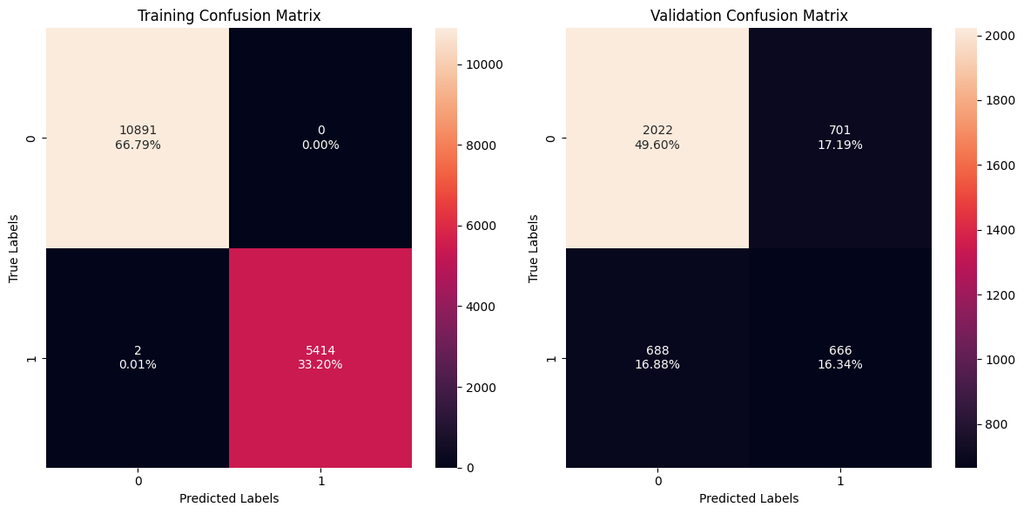

```python
# Plot confusion matrices for training, validation data
plot_confusion_matrices_v2(dtree_default, X_train, y_train, X_val, y_val)
```

```python
# Compute performance metrics on training data set
dtree_default_train_perf = model_performance_classification(
    dtree_default, X_train, y_train
)

# Compute performance metrics on validation data
dtree_default_val_perf = model_performance_classification(
    dtree_default, X_val, y_val
)

# print and compate model performances
dtree_performance = model_performances(dtree_default_train_perf, dtree_default_val_perf)
dtree_performance
```

|  |  | Accuracy | Recall | Precision | F1 |
| --- | --- | --- | --- | --- | --- |
| Training | 0 | 0.999877 | 0.999631 | 1.000000 | 0.999815 |
| Validation | 0 | 0.659308 | 0.491876 | 0.487198 | 0.489526 |

### **M2: Bagging Classifier**

- **Baseline Architecture** - A standard Bagging Classifier using default Decision Trees as base estimators will be trained on the training partition and evaluated on the validation set.
- **Evaluation Framework** - Performance will be assessed across Accuracy, Precision, Recall, and F1 Score, with F1 Score designated as the primary metric to optimize the precision-recall trade-off.
- No hyper parameters will be provided

```python
# create bagging classifier and fit to training data
bagging_classifier = BaggingClassifier(random_state=1)
bagging_classifier.fit(X_train, y_train)
```

```
BaggingClassifier(random_state=1)
```

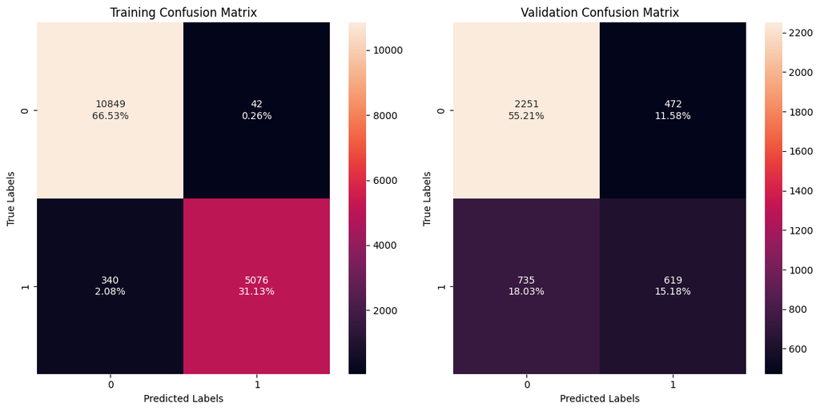

```python
# Plot confusion matrices for training, validation data
plot_confusion_matrices_v2(bagging_classifier, X_train, y_train, X_val, y_val)
```

```python
# Compute performance metrics on training data set
bagging_classifier_train_perf = model_performance_classification(
    bagging_classifier, X_train, y_train
)

# Compute performance metrics on validation data
bagging_classifier_val_perf = model_performance_classification(
    bagging_classifier, X_val, y_val
)

# Print and compare model performances
bagging_classifier_performance = model_performances(bagging_classifier_train_perf, bagging_classifier_val_perf)
bagging_classifier_performance
```

|  |  | Accuracy | Recall | Precision | F1 |
| --- | --- | --- | --- | --- | --- |
| Training | 0 | 0.976574 | 0.937223 | 0.991794 | 0.963736 |
| Validation | 0 | 0.703949 | 0.457164 | 0.567369 | 0.506339 |

### **Model Observation Summary**

- **Training F1** - 0.963 is still very high, indicating near-perfect learning on training data.
- **Validation F1** - 0.506 — much lower, showing the model struggles on unseen data.
- **F1 gap** - A large drop, confirming overfitting is present.
- **Precision gap** - 0.991 (train) vs. 0.567 (val) is also significant, reinforcing overfitting.
- **Compared to Decision Tree** - Smaller performance gap, but still fails to generalize well.

### **M3 : Random Forest Classifier**

- A basic RandomForestClassifier model will be built.
- The model will be fit on training data set and predicted on validation data set.
- All the 4 metrics F1 score, precision, recall and accuracy will be studied with priority to F1 score.
- No hyper parameters will be provided.

```python
# Train the random forest classifier
rf_classifier = RandomForestClassifier(random_state=1)
rf_classifier.fit(X_train, y_train)
```

```
RandomForestClassifier(random_state=1)
```

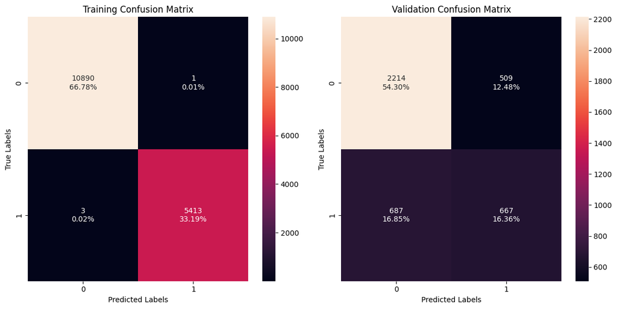

```python
# Plot confusion matrices for training, validation data
plot_confusion_matrices_v2(rf_classifier, X_train, y_train, X_val, y_val)
```

```python
# Compute performance metrics on training data set
rf_classifier_train_perf = model_performance_classification(
    rf_classifier, X_train, y_train
)

# Compute performance metrics on validation data
rf_classifier_val_perf = model_performance_classification(
    rf_classifier, X_val, y_val
)

# print and compare model performances
rf_classifier_performance = model_performances(rf_classifier_train_perf, rf_classifier_val_perf)
rf_classifier_performance
```

|  |  | Accuracy | Recall | Precision | F1 |
| --- | --- | --- | --- | --- | --- |
| Training | 0 | 0.999755 | 0.999446 | 0.999815 | 0.999631 |
| Validation | 0 | 0.706647 | 0.492614 | 0.567177 | 0.527273 |

### **M4 : AdaBoost Classifier**

- A basic AdBoostClassifier model will be built.
- The model will be fit on training data set and predicated on validation data set
- All the 4 metrics F1 score, precision, and accuracy will be studied with priority to F1 score.
- No hyper parameters will be provided

```python
# Train the adaboost classifier
ada_boost_classifier = AdaBoostClassifier(random_state=1)
ada_boost_classifier.fit(X_train, y_train)
```

```
AdaBoostClassifier(random_state=1)
```

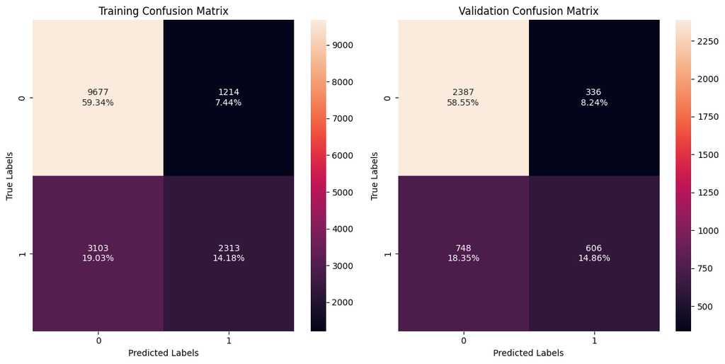

```python
# Plot confusion matrices for training, validation data
plot_confusion_matrices_v2(ada_boost_classifier, X_train, y_train, X_val, y_val)
```

```python
# compute performance metrics on training data set
ada_boost_classifier_train_perf = model_performance_classification(
    ada_boost_classifier, X_train, y_train
)

# compute performance metrics on validation data
ada_boost_classifier_val_perf = model_performance_classification(
    ada_boost_classifier, X_val, y_val
)

# print and compare model performances
ada_boost_classifier_performance = model_performances(ada_boost_classifier_train_perf, ada_boost_classifier_val_perf)
ada_boost_classifier_performance
```

|  |  | Accuracy | Recall | Precision | F1 |
| --- | --- | --- | --- | --- | --- |
| Training | 0 | 0.735267 | 0.427068 | 0.655798 | 0.517276 |
| Validation | 0 | 0.734118 | 0.447563 | 0.643312 | 0.527875 |

### **Model Observation Summary**

- A training F1 score of 0.517 indicates moderate, balanced learning on the training dataset without memorizing noise.
- A validation F1 score of 0.527 closely mirrors training performance, confirming minimal overfitting alongside constrained overall predictive capacity.
- Validation precision reaches 0.643 — the highest among evaluated models—reflecting strong accuracy and low false-positive rates when classifying positive outcomes.
- A suppressed validation recall of 0.447 highlights a high prevalence of false negatives, showing the model frequently misses true positive cases.
- Exceptional stability between training and validation metrics demonstrates strong generalization, indicating the model is well-positioned for further feature engineering and hyperparameter tuning.

### **M5 : Gradient Boost Classifier**

- A basic GradientBoostClassifier model will be built.
- The model will be fit on training data set and predicted on validation data set
- All the 4 metrics F1 Score, Precision, Recall and Accuracy will be studied with priority to F1 score
- No hyper parameters will be provided

```python
# Train the gradient classifier
gradient_boost_classifier = GradientBoostingClassifier(random_state=1)
gradient_boost_classifier.fit(X_train, y_train)
```

```
GradientBoostingClassifier(random_state=1)
```

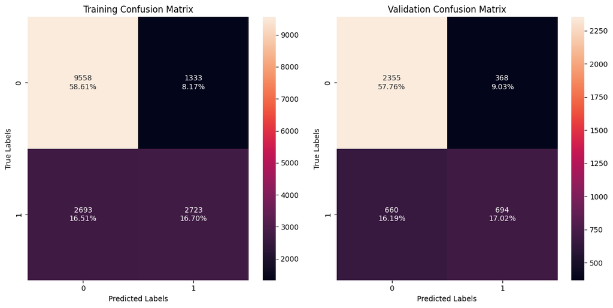

```python
# Plot confusion matrices for training, validation data set
plot_confusion_matrices_v2(gradient_boost_classifier, X_train, y_train, X_val, y_val)
```

```python
# compute performance metrics on training data set
gradient_boost_classifier_train_perf = model_performance_classification(
    gradient_boost_classifier, X_train, y_train
)

# compute performance metrics on validation data
gradient_boost_classifier_val_perf = model_performance_classification(
    gradient_boost_classifier, X_val, y_val
)

# print and compare model performances
gradient_boost_classifier_performance = model_performances(gradient_boost_classifier_train_perf, gradient_boost_classifier_val_perf)
gradient_boost_classifier_performance
```

|  |  | Accuracy | Recall | Precision | F1 |
| --- | --- | --- | --- | --- | --- |
| Training | 0 | 0.753112 | 0.502770 | 0.671351 | 0.574958 |
| Validation | 0 | 0.747854 | 0.512555 | 0.653484 | 0.574503 |

### **M6 : XG Boost Classifier**

- A basic XG Boost Classifier model will be built.
- The model will be fit on training data set and predicted on validation data set
- All the 4 metrics F1 Score, Precision, Recall and Accuracy will be studied with priority to F1 score
- No hyper parameters will be provided

```python
# Train the XG Boost classifier
xg_boost_classifier = XGBClassifier(random_state=1, eval_metric='logloss')
xg_boost_classifier.fit(X_train, y_train)
```

```
XGBClassifier(base_score=None, booster=None, callbacks=None,
              colsample_bylevel=None, colsample_bynode=None,
              colsample_bytree=None, device=None, early_stopping_rounds=None,
              enable_categorical=True, eval_metric='logloss',
              feature_types=None, feature_weights=None, gamma=None,
              grow_policy=None, importance_type=None,
              interaction_constraints=None, learning_rate=None, max_bin=None,
              max_cat_threshold=None, max_cat_to_onehot=None,
              max_delta_step=None, max_depth=None, max_leaves=None,
              min_child_weight=None, missing=nan, monotone_constraints=None,
              multi_strategy=None, n_estimators=None, n_jobs=None,
              num_parallel_tree=None, ...)
```

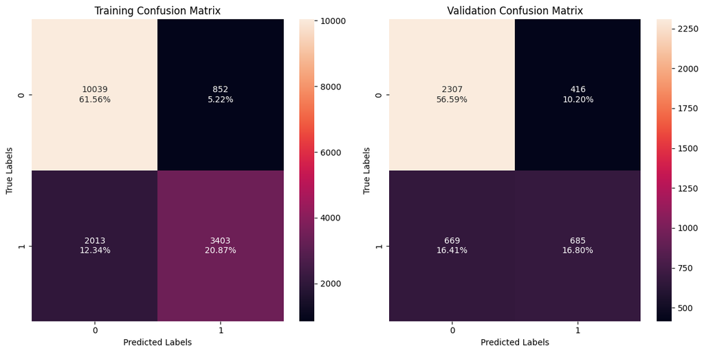

```python
# Plot confusion matrices for training, validation data
plot_confusion_matrices_v2(xg_boost_classifier, X_train, y_train, X_val, y_val)
```

```python
# compute performance metrics on training data set
xg_boost_classifier_train_perf = model_performance_classification(xg_boost_classifier, X_train, y_train)

# compute performance metrics on validation data
xg_boost_classifier_val_perf = model_performance_classification(xg_boost_classifier, X_val, y_val)

# print and compare model performances
xg_boost_classifier_performance = model_performances(xg_boost_classifier_train_perf, xg_boost_classifier_val_perf)
xg_boost_classifier_performance
```

|  |  | Accuracy | Recall | Precision | F1 |
| --- | --- | --- | --- | --- | --- |
| Training | 0 | 0.824309 | 0.628323 | 0.799765 | 0.703753 |
| Validation | 0 | 0.733873 | 0.505908 | 0.622162 | 0.558045 |

### **Model Observation Summary**

- A training F1 score of 0.703 reflects strong capacity to learn underlying patterns within the training split.
- Validation F1 declines to 0.558, signaling moderate high-variance behavior and persistent overfitting.
- Validation precision remains reasonable at 0.622, indicating fair decision confidence when predicting positive outcomes.
- Recall decreases sharply from 0.628 (train) to 0.505 (validation), revealing a high false-negative rate on unseen data
- While overall baseline metric output remains solid, the train-validation gap underscores the need for regularized parameter constraints to improve generalization.

## **Model Building - Oversampled Data**

- Training data will be oversampled for the above models using SMOTE
- The model trained on oversampled data will be validated against the validation dataset

### **Oversample data using SMOTE**

```python
# Fit SMOTE on train data (Synthetic Minority Oversampling Technique)
# Sample the minority 'Certified' Class to 0.67
smote = SMOTE(sampling_strategy=0.67, random_state=1)
X_train_over, y_train_over = smote.fit_resample(X_train, y_train)
```

```python
# Get the new dataset size before and after over sampling
create_sample_comparison(X_train, y_train, X_train_over, y_train_over)
```

|  | Label 1 Count | Label 0 Count | X Shape | Y Shape |
| --- | --- | --- | --- | --- |
| Before Sampling | 5416 | 10891 | (16307, 20) | (16307,) |
| After Sampling | 7296 | 10891 | (18187, 20) | (18187,) |

### **M1 : Decision Tree oversampled (sklearn default)**

The model will be trained on oversampled data with sklearn

```python
# Train the decision tree on oversampled data
dtree_oversampled = DecisionTreeClassifier(random_state=1)
dtree_oversampled.fit(X_train_over, y_train_over)
```

```
DecisionTreeClassifier(random_state=1)
```

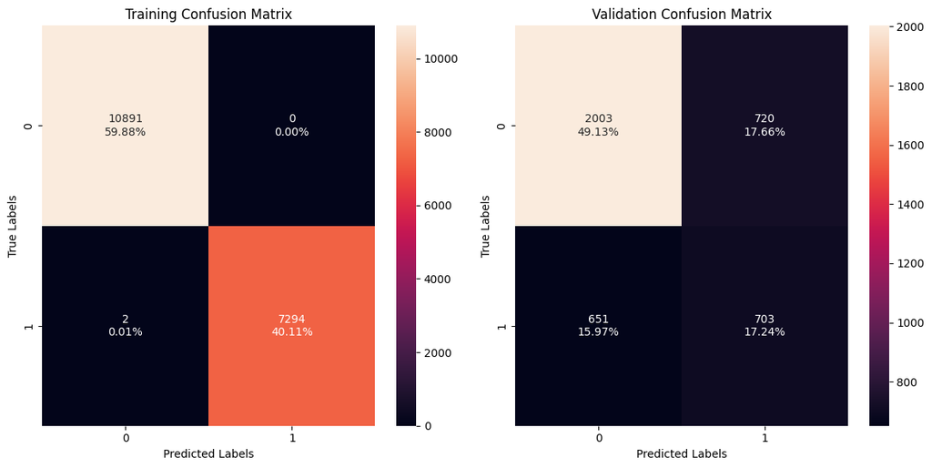

```python
# Plot confusion matrices for training, validation data
plot_confusion_matrices_v2(dtree_oversampled, X_train_over, y_train_over, X_val, y_val)
```

```python
# Compute performance metrics on training dataset
dtree_oversampled_train_perf = model_performance_classification(
    dtree_oversampled, X_train_over, y_train_over
)

# Compute performance metrics on validation dataset
dtree_oversampled_val_perf = model_performance_classification(
    dtree_oversampled, X_val, y_val
)

# print and compare model performances
dtree_oversampled_performance = model_performances(dtree_oversampled_train_perf, dtree_oversampled_val_perf)
dtree_oversampled_performance
```

|  |  | Accuracy | Recall | Precision | F1 |
| --- | --- | --- | --- | --- | --- |
| Training | 0 | 0.999890 | 0.999726 | 1.000000 | 0.999863 |
| Validation | 0 | 0.663723 | 0.519202 | 0.494027 | 0.506302 |

### **Model Observation Summary**

- The oversampled Decision Tree achieves marginal improvements across F1 Score, Precision, and Recall relative to the unweighted baseline model.
- The architecture continues to exhibit severe overfitting, characterized by near-perfect training metrics contrasted against a sharp performance drop on the validation set.

### **M2: Bagging Classifier Oversampled**

```python
# Train the bagging classifier on oversampled dataset
bagging_classifier_oversampled = BaggingClassifier(random_state=1)
bagging_classifier_oversampled.fit(X_train_over, y_train_over)
```

```
BaggingClassifier(random_state=1)
```

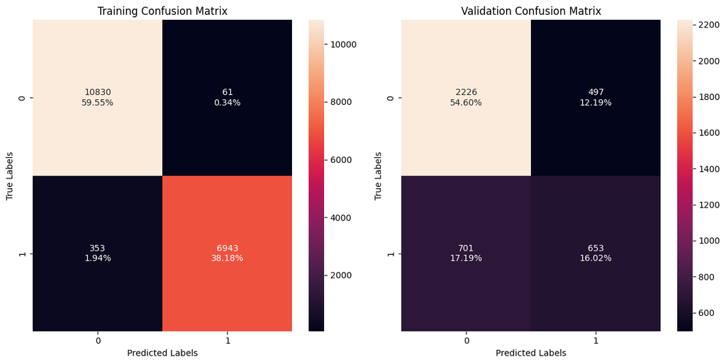

```python
# Plot confusion matrices for training, validation dataset
plot_confusion_matrices_v2(bagging_classifier_oversampled, X_train_over, y_train_over, X_val, y_val)
```

```python
# Compute performance metrics on training data set
bagging_classifier_oversampled_train_perf = model_performance_classification(
    bagging_classifier_oversampled, X_train_over, y_train_over
)

# Compute performance metrics on validation dataset
bagging_classifier_oversampled_val_perf = model_performance_classification(
    bagging_classifier_oversampled, X_val, y_val
)

# print and compare model performances
bagging_classifier_oversampled_performance = model_performances(bagging_classifier_oversampled_train_perf, bagging_classifier_oversampled_val_perf)
bagging_classifier_oversampled_performance
```

|  |  | Accuracy | Recall | Precision | F1 |
| --- | --- | --- | --- | --- | --- |
| Training | 0 | 0.977236 | 0.951617 | 0.991291 | 0.971049 |
| Validation | 0 | 0.706156 | 0.482275 | 0.567826 | 0.521565 |

### **Model Observation Summary**

- Applying oversampling yields only a marginal boost in validation F1 score over the baseline dataset model, offering minimal overall performance lift.
- The model remains bottlenecked by high variance, exhibiting a persistent generalization gap across training and validation F1, Precision, and Recall metrics.

### **M3: Random Forest Classifier oversampled**

```python
# Train the random forest classifier on oversampled dataset
rf_classifier_oversampled = RandomForestClassifier(random_state=1)
rf_classifier_oversampled.fit(X_train_over, y_train_over)
```

```
RandomForestClassifier(random_state=1)
```

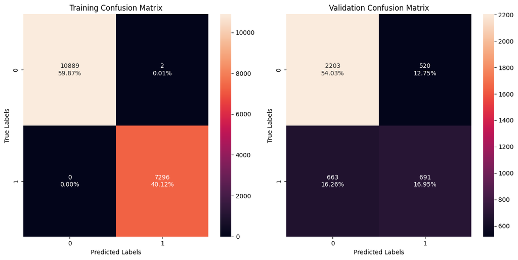

```python
# Plot confusion matrices for training, validation dataset
plot_confusion_matrices_v2(rf_classifier_oversampled, X_train_over, y_train_over, X_val, y_val)
```

```python
# Compute performance metrics on training dataset
rf_classifier_oversampled_train_perf = model_performance_classification(
    rf_classifier_oversampled, X_train_over, y_train_over
)

# Compute performance metrics on validation dataset
rf_classifier_oversampled_val_perf = model_performance_classification(
    rf_classifier_oversampled, X_val, y_val
)

# print and compare model performances
rf_classifier_oversampled_performance = model_performances(rf_classifier_oversampled_train_perf, rf_classifier_oversampled_val_perf)
rf_classifier_oversampled_performance
```

|  |  | Accuracy | Recall | Precision | F1 |
| --- | --- | --- | --- | --- | --- |
| Training | 0 | 0.999890 | 1.00000 | 0.999726 | 0.999863 |
| Validation | 0 | 0.709836 | 0.51034 | 0.570603 | 0.538791 |

### **Model Observation Summary**

- Oversampling produces slight gains in validation F1 score and accuracy, alongside a modest improvement in recall.
- Near-perfect training metrics across both baseline and resampled iterations confirm that oversampling fails to resolve the model's severe overfitting.

### **M4: AdaBoostClassifier oversampled**

```python
# Train the adaboost classifier on oversampled dataset
ada_boost_classifier_oversampled = AdaBoostClassifier(random_state=1)
ada_boost_classifier_oversampled.fit(X_train_over, y_train_over)
```

```
AdaBoostClassifier(random_state=1)
```

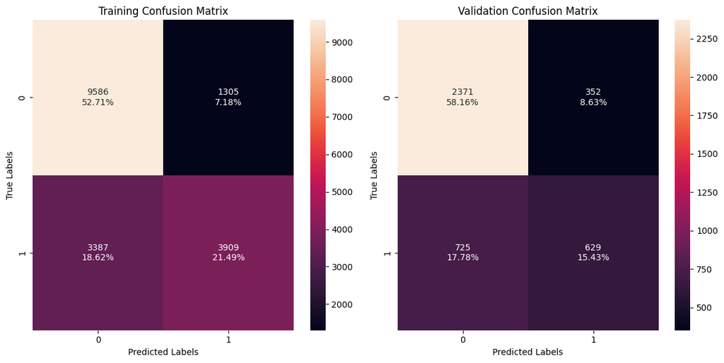

```python
# Plot confusion matrices for training, validation dataset
plot_confusion_matrices_v2(ada_boost_classifier_oversampled, X_train_over, y_train_over, X_val, y_val)
```

```python
# Compute performance metrics on training dataset
ada_boost_classifier_oversampled_train_perf = model_performance_classification(
    ada_boost_classifier_oversampled, X_train_over, y_train_over
)

# Compute performance metrics on validation dataset
ada_boost_classifier_oversampled_val_perf = model_performance_classification(
    ada_boost_classifier_oversampled, X_val, y_val
)

# print and compare model performances
ada_boost_classifier_oversampled_performance = model_performances(ada_boost_classifier_oversampled_train_perf, ada_boost_classifier_oversampled_val_perf)
ada_boost_classifier_oversampled_performance
```

|  |  | Accuracy | Recall | Precision | F1 |
| --- | --- | --- | --- | --- | --- |
| Training | 0 | 0.742014 | 0.535773 | 0.749712 | 0.624940 |
| Validation | 0 | 0.735835 | 0.464549 | 0.641182 | 0.538758 |

### **Model Observation Summary**

- Oversampling yields marginal lifts in F1 score and recall over the original model, yet absolute performance remains capped by low recall, reflecting a high false-negative rate on minority class predictions.
- Precision metrics demonstrate fair baseline reliability without offering strong decision confidence for positive class predictions.
- Modest gaps between training and validation metrics confirm strong generalization and a lack of severe overfitting compared to high-variance baseline iterations.
- While serving as a stable benchmark, the model requires hyperparameter tuning, targeted feature engineering, or advanced ensemble algorithms to achieve production-grade performance.

### **M5: Gradient Boost Classifier oversampled**

```python
# Train the gradient boost classifier on oversampled dataset
gradient_boost_classifier_oversampled = GradientBoostingClassifier(random_state=1)
gradient_boost_classifier_oversampled.fit(X_train_over, y_train_over)
```

```
GradientBoostingClassifier(random_state=1)
```

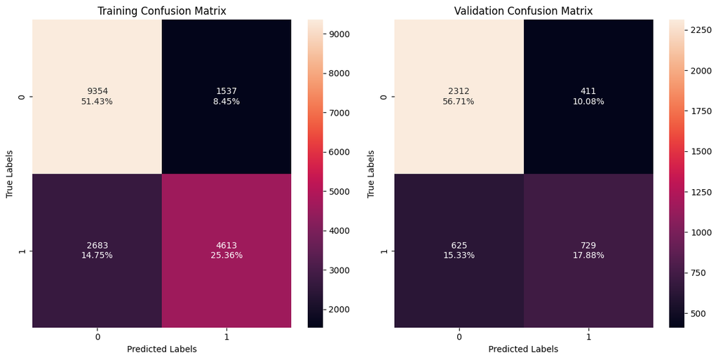

```python
# Plot confusion matrices for training, validation dataset
plot_confusion_matrices_v2(gradient_boost_classifier_oversampled, X_train_over, y_train_over, X_val, y_val)
```

```python
# Compute performance metrics on training dataset
gradient_boost_classifier_oversampled_train_perf = model_performance_classification(
    gradient_boost_classifier_oversampled, X_train_over, y_train_over
)

# Compute performance metrics on validation dataset
gradient_boost_classifier_oversampled_val_perf = model_performance_classification(
    gradient_boost_classifier_oversampled, X_val, y_val
)

# print and compare model performances
gradient_boost_classifier_oversampled_performance = model_performances(gradient_boost_classifier_oversampled_train_perf, gradient_boost_classifier_oversampled_val_perf)
gradient_boost_classifier_oversampled_performance
```

|  |  | Accuracy | Recall | Precision | F1 |
| --- | --- | --- | --- | --- | --- |
| Training | 0 | 0.767966 | 0.632264 | 0.750081 | 0.686152 |
| Validation | 0 | 0.745892 | 0.538405 | 0.639474 | 0.584603 |

### **M6: XG Boost Classifier oversampled**

```python
# Train the XG Boost classifier on oversampled dataset
xg_boost_classifier_oversampled = XGBClassifier(random_state=1, eval_metric='logloss')
xg_boost_classifier_oversampled.fit(X_train_over, y_train_over)
```

```
XGBClassifier(base_score=None, booster=None, callbacks=None,
              colsample_bylevel=None, colsample_bynode=None,
              colsample_bytree=None, device=None, early_stopping_rounds=None,
              enable_categorical=True, eval_metric='logloss',
              feature_types=None, feature_weights=None, gamma=None,
              grow_policy=None, importance_type=None,
              interaction_constraints=None, learning_rate=None, max_bin=None,
              max_cat_threshold=None, max_cat_to_onehot=None,
              max_delta_step=None, max_depth=None, max_leaves=None,
              min_child_weight=None, missing=nan, monotone_constraints=None,
              multi_strategy=None, n_estimators=None, n_jobs=None,
              num_parallel_tree=None, ...)
```

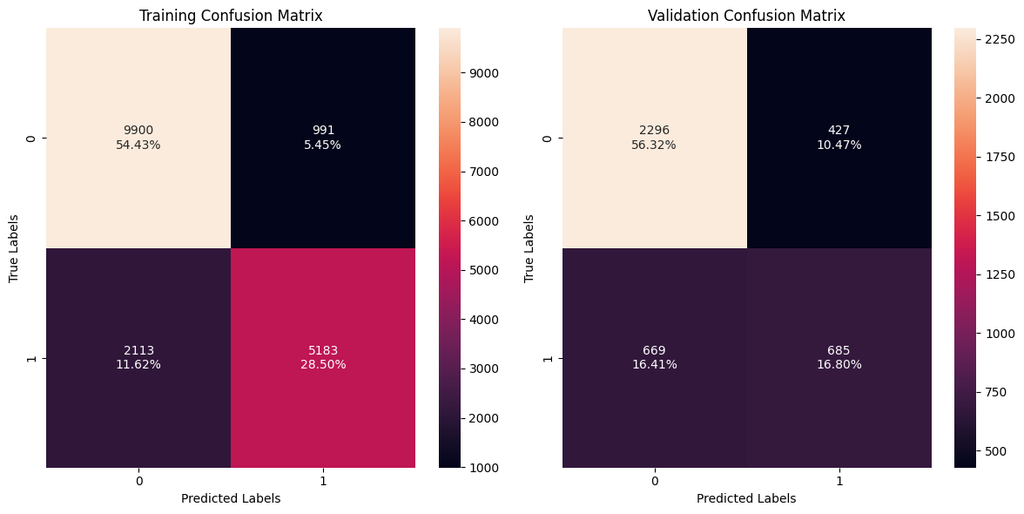

```python
# Plot confusion matrices for training, validation dataset
plot_confusion_matrices_v2(xg_boost_classifier_oversampled, X_train_over, y_train_over, X_val, y_val)
```

```python
# Compute performance metrics on training dataset
xg_boost_classifier_oversampled_train_perf = model_performance_classification(xg_boost_classifier_oversampled, X_train_over, y_train_over)

# Compute performance metrics on validation dataset
xg_boost_classifier_oversampled_val_perf = model_performance_classification(xg_boost_classifier_oversampled, X_val, y_val)

# print and compare model performances
xg_boost_classifier_oversampled_performance = model_performances(xg_boost_classifier_oversampled_train_perf, xg_boost_classifier_oversampled_val_perf)
xg_boost_classifier_oversampled_performance
```

|  |  | Accuracy | Recall | Precision | F1 |
| --- | --- | --- | --- | --- | --- |
| Training | 0 | 0.829329 | 0.710389 | 0.839488 | 0.769562 |
| Validation | 0 | 0.731175 | 0.505908 | 0.616007 | 0.555556 |

## **Model Building - Undersampled Data**

```python
# Fit random under sampler on the train dataset
random_under_sampler = RandomUnderSampler(sampling_strategy=1, random_state=1)
X_train_under, y_train_under = random_under_sampler.fit_resample(X_train, y_train)
```

```python
# Get the new dataset size before and after undersampling
create_sample_comparison(X_train, y_train, X_train_under, y_train_under)
```

|  | Label 1 Count | Label 0 Count | X Shape | Y Shape |
| --- | --- | --- | --- | --- |
| Before Sampling | 5416 | 10891 | (16307, 20) | (16307,) |
| After Sampling | 5416 | 5416 | (10832, 20) | (10832,) |

### **M1: Decision Tree undersampled (sklearn default)**

```python
# Train the decision tree on under sampled dataset
dtree_undersampled = DecisionTreeClassifier(random_state=1)
dtree_undersampled.fit(X_train_under, y_train_under)
```

```
DecisionTreeClassifier(random_state=1)
```

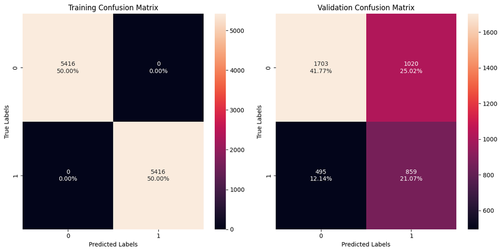

```python
# Plot confusion matrices for training data undersampled and validation data
plot_confusion_matrices_v2(dtree_undersampled, X_train_under, y_train_under, X_val, y_val)
```

```python
# Compute performance metrics on training data set
dtree_undersampled_train_perf = model_performance_classification(
    dtree_undersampled, X_train_under, y_train_under
)

# Compute performance metrics on validation data set
dtree_undersampled_val_perf = model_performance_classification(
    dtree_undersampled, X_val, y_val
)

# print and compare model performances
dtree_undersampled_performance = model_performances(dtree_undersampled_train_perf, dtree_undersampled_val_perf)
dtree_undersampled_performance
```

|  |  | Accuracy | Recall | Precision | F1 |
| --- | --- | --- | --- | --- | --- |
| Training | 0 | 1.000000 | 1.000000 | 1.000000 | 1.000000 |
| Validation | 0 | 0.628403 | 0.634417 | 0.457158 | 0.531395 |

### **Model Observation Summary**

- Undersampling yields marginal F1 and recall lifts over original and oversampled Decision Tree variants, but causes noticeable drops in accuracy and precision.
- The substantial disparity between training and validation scores confirms that the model continues to suffer from severe overfitting.

### **M2: Bagging Classifier undersampled**

```python
# Train the decision tree on under sampled dataset
bagging_classifier_undersampled = BaggingClassifier(random_state=1)
bagging_classifier_undersampled.fit(X_train_under, y_train_under)
```

```
BaggingClassifier(random_state=1)
```

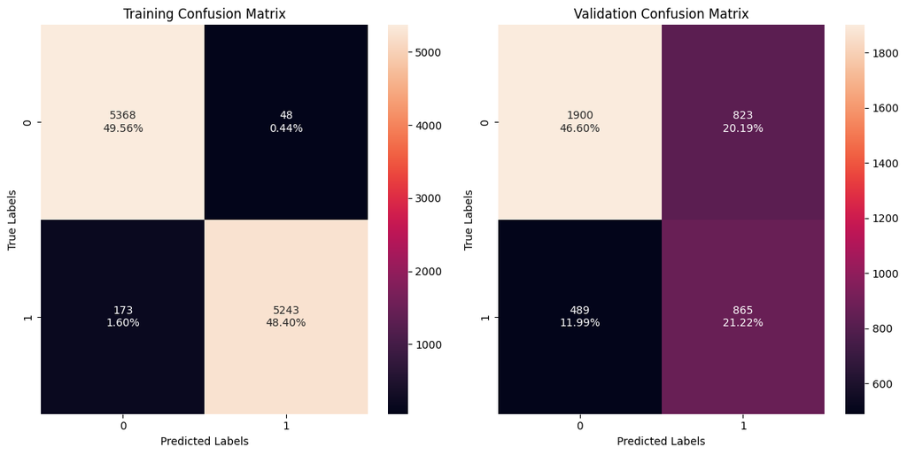

```python
# Plot confusion matrices for training data undersampled and validation dataset
plot_confusion_matrices_v2(bagging_classifier_undersampled, X_train_under, y_train_under, X_val, y_val)
```

```python
# Compute performance metrics on training dataset
bagging_classifier_undersampled_train_perf = model_performance_classification(
    bagging_classifier_undersampled, X_train_under, y_train_under
)

# Compute performance metrics on validation dataset
bagging_classifier_undersampled_val_perf = model_performance_classification(
    bagging_classifier_undersampled, X_val, y_val
)

# print and compare model performances
bagging_classifier_undersampled_performance = model_performances(bagging_classifier_undersampled_train_perf, bagging_classifier_undersampled_val_perf)
bagging_classifier_undersampled_performance
```

|  |  | Accuracy | Recall | Precision | F1 |
| --- | --- | --- | --- | --- | --- |
| Training | 0 | 0.979597 | 0.968058 | 0.990928 | 0.979359 |
| Validation | 0 | 0.678195 | 0.638848 | 0.512441 | 0.568705 |

### **Model Observation Summary**

- The undersampled Bagging Classifier mirrors the decision tree pattern, yielding a noticeable boost in recall and a marginal F1 lift at the expense of reduced precision and overall accuracy.
- Despite the ensembling strategy, a wide performance disparity between training and validation sets confirms that the model remains severely overfitted.

### **M3: Random Forest Classifier undersampled**

```python
# Train the random forest classifier on under sampled dataset
rf_classifier_undersampled = RandomForestClassifier(random_state=1)
rf_classifier_undersampled.fit(X_train_under, y_train_under)
```

```
RandomForestClassifier(random_state=1)
```

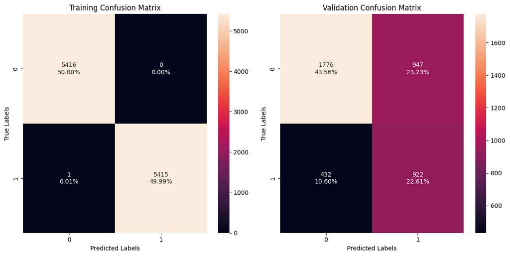

```python
# Plot confusion matrices for training data undersampled and validation dataset
plot_confusion_matrices_v2(rf_classifier_undersampled, X_train_under, y_train_under, X_val, y_val)
```

```python
# Compute performance metrics on training dataset
rf_classifier_undersampled_train_perf = model_performance_classification(
    rf_classifier_undersampled, X_train_under, y_train_under
)

# Compute performance metrics on validation dataset
rf_classifier_undersampled_val_perf = model_performance_classification(
    rf_classifier_undersampled, X_val, y_val
)

# print and compare model performances
rf_classifier_undersampled_performance = model_performances(rf_classifier_undersampled_train_perf, rf_classifier_undersampled_val_perf)
rf_classifier_undersampled_performance
```

|  |  | Accuracy | Recall | Precision | F1 |
| --- | --- | --- | --- | --- | --- |
| Training | 0 | 0.999908 | 0.999815 | 1.000000 | 0.999908 |
| Validation | 0 | 0.661761 | 0.680945 | 0.493312 | 0.572138 |

### **Model Observation Summary**

- Undersampling produces a significant gain in recall and a marginal $F_1$ lift, though this comes at the cost of lower overall accuracy and precision.
- The undersampled Random Forest classifier continues to suffer from severe overfitting, evidenced by a wide performance gap between training and validation metrics.

### **M4: Ada Boost Classifier undersampled**

```python
# Train the Ada Boost classifier on under sampled dataset
ada_boost_classifier_undersampled = AdaBoostClassifier(random_state=1)
ada_boost_classifier_undersampled.fit(X_train_under, y_train_under)
```

```
AdaBoostClassifier(random_state=1)
```

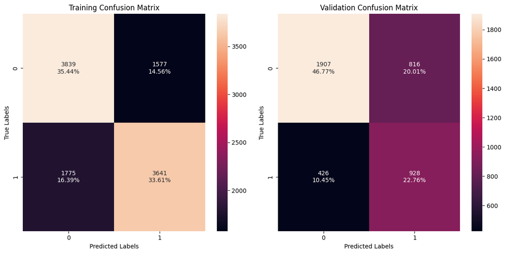

```python
# Plot confusion matrices for training data undersampled and validation data
plot_confusion_matrices_v2(ada_boost_classifier_undersampled, X_train_under, y_train_under, X_val, y_val)
```

```python
# Compute performance metrics on training dataset
ada_boost_classifier_undersampled_train_perf = model_performance_classification(
    ada_boost_classifier_undersampled, X_train_under, y_train_under
)

# Compute performance metrics on validation dataset
ada_boost_classifier_undersampled_val_perf = model_performance_classification(
    ada_boost_classifier_undersampled, X_val, y_val
)

# print and compare model performances
ada_boost_classifier_undersampled_performance = model_performances(ada_boost_classifier_undersampled_train_perf, ada_boost_classifier_undersampled_val_perf)
ada_boost_classifier_undersampled_performance
```

|  |  | Accuracy | Recall | Precision | F1 |
| --- | --- | --- | --- | --- | --- |
| Training | 0 | 0.690547 | 0.672267 | 0.697777 | 0.684785 |
| Validation | 0 | 0.695364 | 0.685377 | 0.532110 | 0.599096 |

### **Model Observation Summary**

- Undersampling drives a significant gain in recall alongside a marginal F1 lift, balanced by expected drops in overall accuracy and precision.
- Unlike tree-heavy ensembles, the undersampled AdaBoost classifier exhibits minimal train-validation metric gaps, confirming strong generalization without severe overfitting.

### **M5: Gradient Boost Classifier undersampled**:

```python
# Train the Gradient Boost classifier on under sampled data
gradient_boost_classifier_undersampled = GradientBoostingClassifier(random_state=1)
gradient_boost_classifier_undersampled.fit(X_train_under, y_train_under)
```

```
GradientBoostingClassifier(random_state=1)
```

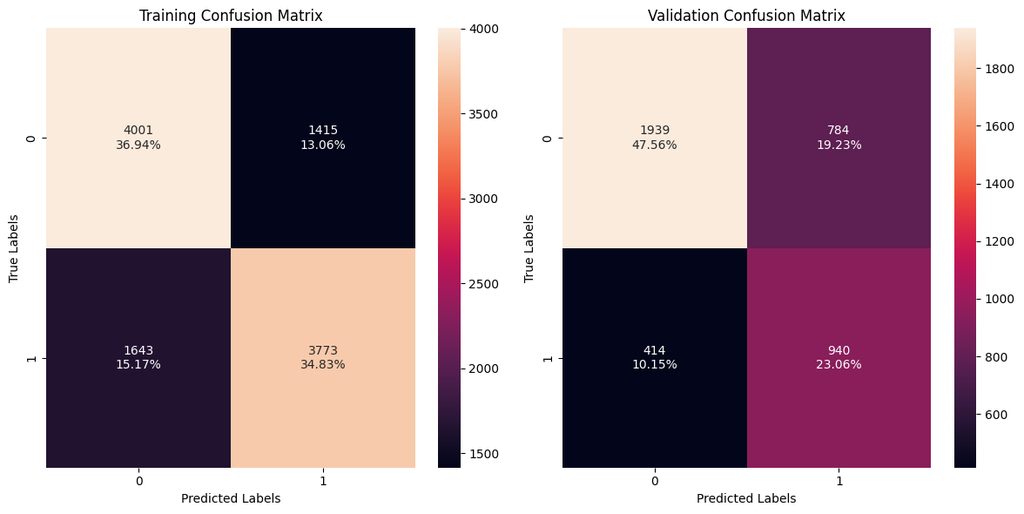

```python
# Plot confusion matrices for training data undersampled and validation dataset
plot_confusion_matrices_v2(gradient_boost_classifier_undersampled, X_train_under, y_train_under, X_val, y_val)
```

```python
# Compute performance metrics on training dataset
gradient_boost_classifier_undersampled_train_perf = model_performance_classification(
    gradient_boost_classifier_undersampled, X_train_under, y_train_under
)

# Compute performance metrics on validation dataset
gradient_boost_classifier_undersampled_val_perf = model_performance_classification(
    gradient_boost_classifier_undersampled, X_val, y_val
)

# Print and compare model performances
gradient_boost_classifier_undersampled_performance = model_performances(gradient_boost_classifier_undersampled_train_perf, gradient_boost_classifier_undersampled_val_perf)
gradient_boost_classifier_undersampled_performance
```

|  |  | Accuracy | Recall | Precision | F1 |
| --- | --- | --- | --- | --- | --- |
| Training | 0 | 0.717688 | 0.696640 | 0.727255 | 0.711618 |
| Validation | 0 | 0.706156 | 0.694239 | 0.545244 | 0.610786 |

### **Model Observation Summary**

- Applying undersampling to the Gradient Boosting classifier yields a substantial lift in recall and a marginal increase in F1 score, accompanied by significant drops in precision and overall accuracy.
- While minimal training-validation gaps in accuracy and recall point to stable overall learning, noticeable disparities in precision and F1 scores reveal mild underlying overfitting.

### **M6: XG Boost Classifier undersampled**:

```python
# Train the XG Boost classifier on under sampled data
xg_boost_classifier_undersampled = XGBClassifier(random_state=1, eval_metric='logloss')
xg_boost_classifier_undersampled.fit(X_train_under, y_train_under)
```

```
XGBClassifier(base_score=None, booster=None, callbacks=None,
              colsample_bylevel=None, colsample_bynode=None,
              colsample_bytree=None, device=None, early_stopping_rounds=None,
              enable_categorical=True, eval_metric='logloss',
              feature_types=None, feature_weights=None, gamma=None,
              grow_policy=None, importance_type=None,
              interaction_constraints=None, learning_rate=None, max_bin=None,
              max_cat_threshold=None, max_cat_to_onehot=None,
              max_delta_step=None, max_depth=None, max_leaves=None,
              min_child_weight=None, missing=nan, monotone_constraints=None,
              multi_strategy=None, n_estimators=None, n_jobs=None,
              num_parallel_tree=None, ...)
```

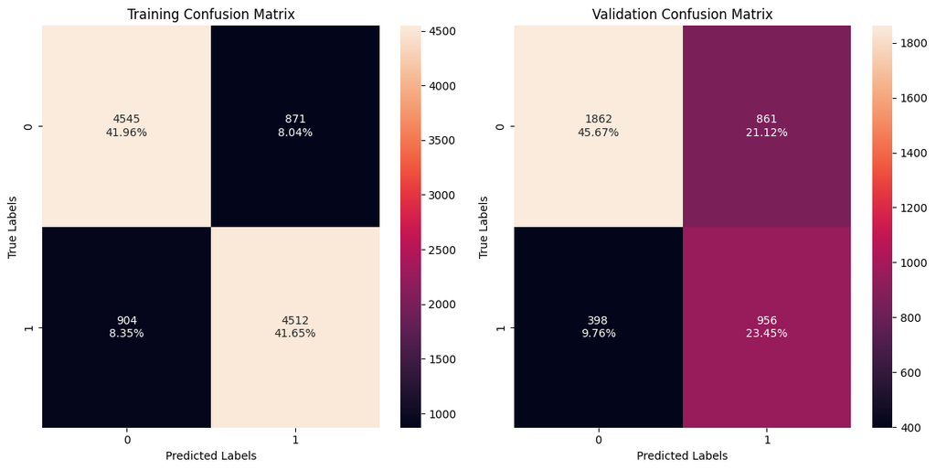

```python
# Plot confusion matrices for training data undersampled and validation data
plot_confusion_matrices_v2(xg_boost_classifier_undersampled, X_train_under, y_train_under, X_val, y_val)
```

```python
# Compute performance metrics on training dataset
xg_boost_classifier_undersampled_train_perf = model_performance_classification(xg_boost_classifier_undersampled, X_train_under, y_train_under)

# Compute performance metrics on validation dataset
xg_boost_classifier_undersampled_val_perf = model_performance_classification(xg_boost_classifier_undersampled, X_val, y_val)

# Print and compare model performances
xg_boost_classifier_undersampled_performance = model_performances(xg_boost_classifier_undersampled_train_perf, xg_boost_classifier_undersampled_val_perf)
xg_boost_classifier_undersampled_performance
```

|  |  | Accuracy | Recall | Precision | F1 |
| --- | --- | --- | --- | --- | --- |
| Training | 0 | 0.836134 | 0.833087 | 0.838194 | 0.835633 |
| Validation | 0 | 0.691195 | 0.706056 | 0.526142 | 0.602964 |

### **Model Observation Summary**

- Applying undersampling to the XGBoost classifier drives an increase in recall and a marginal F1 lift, offset by noticeable drops in precision and accuracy.
- The persistent divergence between training and validation metrics indicates that the model remains moderately overfitted.

## **Hyperparameter Tuning**

**Candidate Selection:** The top 3 performing models will be selected from an evaluation matrix of 18 total configurations (6 core modeling techniques evaluated across 3 sampling regimes: baseline original, oversampled, and undersampled).

**Evaluated Algorithms:**

1. Decision Tree Classifier
2. Bagging Classifier
3. Random Forest Classifier
4. AdaBoost Classifier
5. Gradient Boosting Classifier
6. XGBoost Classifier

### **Model Performance List**

```python
# Create the matrix to display the techniques and the models with its performance on training and testing data
model_names = [
    'Decision Tree default',
    'Decision Tree oversampled',
    'Decision Tree undersampled',
    'Bagging Classifier default',
    'Bagging Classifier oversampled',
    'Bagging Classifier undersampled',
    'Random Forest default',
    'Random Forest oversampled',
    'Random Forest undersampled',
    'AdaBoost Classifier default',
    'AdaBoost Classifier oversampled',
    'AdaBoost Classifier undersampled',
    'Gradient Boosting Classifier default',
    'Gradient Boosting Classifier oversampled',
    'Gradient Boosting Classifier undersampled',
    'XGBoost Classifier default',
    'XGBoost Classifier oversampled',
    'XGBoost Classifier undersampled'
]

models_without_tuning = pd.concat([
    dtree_performance,
    dtree_oversampled_performance,
    dtree_undersampled_performance,
    bagging_classifier_performance,
    bagging_classifier_oversampled_performance,
    bagging_classifier_undersampled_performance,
    rf_classifier_performance,
    rf_classifier_oversampled_performance,
    rf_classifier_undersampled_performance,
    ada_boost_classifier_performance,
    ada_boost_classifier_oversampled_performance,
    ada_boost_classifier_undersampled_performance,
    gradient_boost_classifier_performance,
    gradient_boost_classifier_oversampled_performance,
    gradient_boost_classifier_undersampled_performance,
    xg_boost_classifier_performance,
    xg_boost_classifier_oversampled_performance,
    xg_boost_classifier_undersampled_performance
], axis=0, keys = model_names)
models_without_tuning
```

|  |  |  | Accuracy | Recall | Precision | F1 |
| --- | --- | --- | --- | --- | --- | --- |
| Decision Tree default | Training | 0 | 0.999877 | 0.999631 | 1.000000 | 0.999815 |
|  | Validation | 0 | 0.659308 | 0.491876 | 0.487198 | 0.489526 |
| Decision Tree oversampled | Training | 0 | 0.999890 | 0.999726 | 1.000000 | 0.999863 |
|  | Validation | 0 | 0.663723 | 0.519202 | 0.494027 | 0.506302 |
| Decision Tree undersampled | Training | 0 | 1.000000 | 1.000000 | 1.000000 | 1.000000 |
|  | Validation | 0 | 0.628403 | 0.634417 | 0.457158 | 0.531395 |
| Bagging Classifier default | Training | 0 | 0.976574 | 0.937223 | 0.991794 | 0.963736 |
|  | Validation | 0 | 0.703949 | 0.457164 | 0.567369 | 0.506339 |
| Bagging Classifier oversampled | Training | 0 | 0.977236 | 0.951617 | 0.991291 | 0.971049 |
|  | Validation | 0 | 0.706156 | 0.482275 | 0.567826 | 0.521565 |
| Bagging Classifier undersampled | Training | 0 | 0.979597 | 0.968058 | 0.990928 | 0.979359 |
|  | Validation | 0 | 0.678195 | 0.638848 | 0.512441 | 0.568705 |
| Random Forest default | Training | 0 | 0.999755 | 0.999446 | 0.999815 | 0.999631 |
|  | Validation | 0 | 0.706647 | 0.492614 | 0.567177 | 0.527273 |
| Random Forest oversampled | Training | 0 | 0.999890 | 1.000000 | 0.999726 | 0.999863 |
|  | Validation | 0 | 0.709836 | 0.510340 | 0.570603 | 0.538791 |
| Random Forest undersampled | Training | 0 | 0.999908 | 0.999815 | 1.000000 | 0.999908 |
|  | Validation | 0 | 0.661761 | 0.680945 | 0.493312 | 0.572138 |
| AdaBoost Classifier default | Training | 0 | 0.735267 | 0.427068 | 0.655798 | 0.517276 |
|  | Validation | 0 | 0.734118 | 0.447563 | 0.643312 | 0.527875 |
| AdaBoost Classifier oversampled | Training | 0 | 0.742014 | 0.535773 | 0.749712 | 0.624940 |
|  | Validation | 0 | 0.735835 | 0.464549 | 0.641182 | 0.538758 |
| AdaBoost Classifier undersampled | Training | 0 | 0.690547 | 0.672267 | 0.697777 | 0.684785 |
|  | Validation | 0 | 0.695364 | 0.685377 | 0.532110 | 0.599096 |
| Gradient Boosting Classifier default | Training | 0 | 0.753112 | 0.502770 | 0.671351 | 0.574958 |
|  | Validation | 0 | 0.747854 | 0.512555 | 0.653484 | 0.574503 |
| Gradient Boosting Classifier oversampled | Training | 0 | 0.767966 | 0.632264 | 0.750081 | 0.686152 |
|  | Validation | 0 | 0.745892 | 0.538405 | 0.639474 | 0.584603 |
| Gradient Boosting Classifier undersampled | Training | 0 | 0.717688 | 0.696640 | 0.727255 | 0.711618 |
|  | Validation | 0 | 0.706156 | 0.694239 | 0.545244 | 0.610786 |
| XGBoost Classifier default | Training | 0 | 0.824309 | 0.628323 | 0.799765 | 0.703753 |
|  | Validation | 0 | 0.733873 | 0.505908 | 0.622162 | 0.558045 |
| XGBoost Classifier oversampled | Training | 0 | 0.829329 | 0.710389 | 0.839488 | 0.769562 |
|  | Validation | 0 | 0.731175 | 0.505908 | 0.616007 | 0.555556 |
| XGBoost Classifier undersampled | Training | 0 | 0.836134 | 0.833087 | 0.838194 | 0.835633 |
|  | Validation | 0 | 0.691195 | 0.706056 | 0.526142 | 0.602964 |

## **Selection of Top 3 Models for hyper-parameter tuning**

**Gradient Boost (Oversampled)**

- A precision score of 0.6394 ranks among the highest evaluated, directly advancing the core objective of minimizing false-positive misclassifications.
- An F1 score of 0.5846 establishes a robust balance between decision precision and minority instance detection.
- A recall rate of 0.5384 provides sufficient sensitivity to prevent excessive false negatives on minority class predictions.
- The pipeline effectively mitigates class imbalance by leveraging the combined strengths of synthetic oversampling and gradient boosting dynamics.

**XGBoost (Oversampled)**

- A competitive precision score of 0.6160 demonstrates consistent decision confidence across model variations.
- An F1 score of 0.5555 maintains a reliable equilibrium between overall accuracy and sensitivity.
- A recall rate of 0.5059 delivers above-average minority detection relative to comparable high-precision candidates.
- Robust structural stability makes this model architecture highly scalable for complex, high-volume production deployments.

**AdaBoost (Oversampled)**

## **1. Tuning AdaBoost (Oversampled)**

### **Hyper Parameters**

Below hyper parameters will be used for AdaBoost tuning

- **base_estimator** - The underlying base learner from which the boosted ensemble is built (defaults to a Decision Tree with max_depth=1).
- **n_estimators** - The maximum number of weak learners constructed before boosting terminates (defaults to 50).
- **learning_rate** - The shrinkage factor applied to adjust each classifier's contribution, governing a direct trade-off with *n_estimators*.

### **Cross Validation**

For cross validation GridSearchCV will be used

- scoring will be done for precision and F1 score
- To parallelise n_jobs=-1 will be used

```python
# Grid of parameters to choose from
ada_parameters = {
    # Different max_depth for estimator
    "estimator": [DecisionTreeClassifier(max_depth=3, random_state=1), DecisionTreeClassifier(max_depth=4, random_state=1), DecisionTreeClassifier(max_depth=5, random_state=1)],
    "n_estimators": [100, 200, 300, 400],
    "learning_rate": [0.1, 0.2]
}

# Precision and F1 scoring used to compare parameter combinations
ada_scoring = {
    'precision': metrics.make_scorer(metrics.precision_score),
    'f1': metrics.make_scorer(metrics.f1_score)
}

# Create and run the grid search for all above combinations of hyper parameters
# Use ada_boost_classifier_over model
ada_grid_search = GridSearchCV(ada_boost_classifier_oversampled, ada_parameters, scoring=ada_scoring, refit='f1', cv=5, n_jobs=-1)
ada_grid_search = ada_grid_search.fit(X_train_over, y_train_over)

# Set the clf to the best combination of parameters
ada_boost_classifier_tuned = ada_grid_search.best_estimator_

# Fit the best algorithm to the data.
ada_boost_classifier_tuned.fit(X_train_over, y_train_over)
```

```
AdaBoostClassifier(estimator=DecisionTreeClassifier(max_depth=5,
                                                    random_state=1),
                   learning_rate=0.1, n_estimators=300, random_state=1)
```

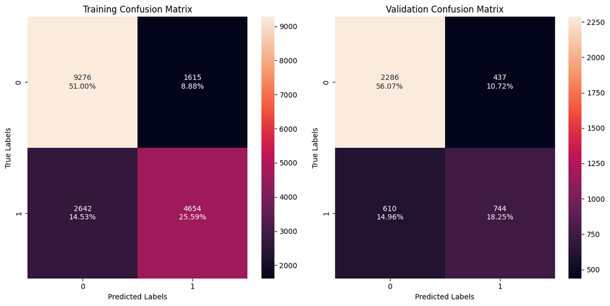

```python
# Plot confusion matrices for training, validation data
plot_confusion_matrices_v2(ada_boost_classifier_tuned, X_train_over, y_train_over, X_val, y_val)
```

```python
#Compute performance metrics on training dataset
ada_boost_classifier_tuned_train_perf = model_performance_classification(ada_boost_classifier_tuned, X_train_over, y_train_over)

#Compute performance metrics on validation dataset
ada_boost_classifier_tuned_val_perf = model_performance_classification(ada_boost_classifier_tuned, X_val, y_val)

# print and compare model performances
ada_boost_classifier_tuned_performance = model_performances(ada_boost_classifier_tuned_train_perf, ada_boost_classifier_tuned_val_perf)
ada_boost_classifier_tuned_performance
```

|  |  | Accuracy | Recall | Precision | F1 |
| --- | --- | --- | --- | --- | --- |
| Training | 0 | 0.765932 | 0.637884 | 0.742383 | 0.686178 |
| Validation | 0 | 0.743194 | 0.549483 | 0.629975 | 0.586982 |

### **Importances**

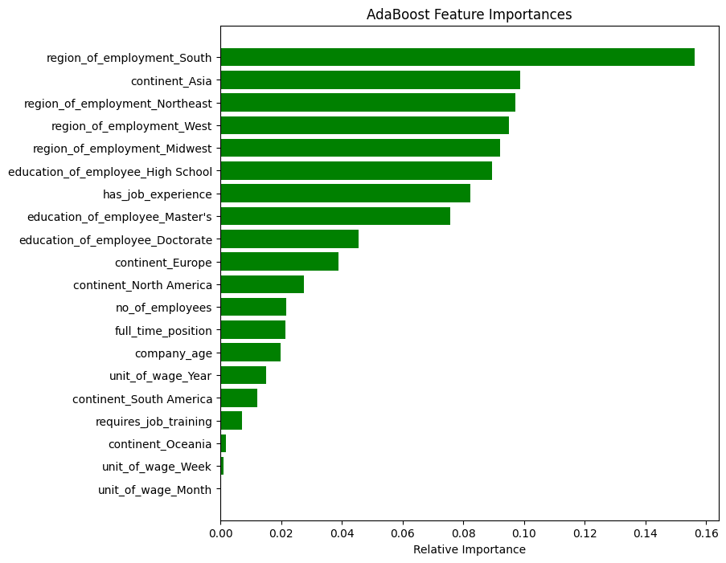

```python
# compute and print the important features
ada_boost_importances = ada_boost_classifier_tuned.feature_importances_
ada_indices = np.argsort(ada_boost_importances)
ada_feature_names = list(X.columns)

# plot the feature importance
plt.figure(figsize=(8,8))
plt.title('AdaBoost Feature Importances')
plt.barh(range(len(ada_indices)), ada_boost_importances[ada_indices], color='green', align='center')
plt.yticks(range(len(ada_indices)), [ada_feature_names[i] for i in ada_indices])
plt.xlabel('Relative Importance')
plt.show()
```

### **Model Observation Summary**

- Adaboost hyper-tuned model considers the regions of employment south as the important feature for applicants getting visas certified
- This is followed by applicant continent Asia and various regions of employment.

### **2.Tuning Gradient Boost (oversampled)**

### **Hyper Parameters**

Following hyper parameters will be used for Gradient Boost tuning on the oversampled model

1. *n_estimators* - The total number of sequential boosting stages to perform during ensemble training.
2. *subsample* - The fraction of training instances randomly sampled to fit each individual base learner.
3. *max_features* - The number or proportion of features evaluated when determining the optimal split at each node.
4. *learning_rate* - The shrinkage factor applied to scale each tree's contribution, establishing a direct trade-off with *n_estimators*.

### **Cross Validation**

For cross validation GridSearchCV will be used

1. scoring will be done for precision and F1 score
2. To parallelise n_jobs=-1 will be used

```python
# Grid of hyper parameters to choose from GridSeachCV using Gradient Boosting
gb_parameters = {
    "n_estimators":[100, 150, 200, 250],
    "subsample":[0.8,0.9,1],
    "max_features":[0.7,0.8,0.9,1],
    "learning_rate":[0.1,0.2,0.3]
}

# Precision and F1 scoring used to compare parameter combinations
gb_scoring = {
    'precision': metrics.make_scorer(metrics.precision_score),
    'f1': metrics.make_scorer(metrics.f1_score)
}

# Create and run the grid search for all above combinations of hyper parameters
# Use gradient_boost_classifier_oversampled model
gb_grid_search = GridSearchCV(gradient_boost_classifier_oversampled, gb_parameters, scoring=gb_scoring, refit='f1', cv=5, n_jobs=-1)
gb_grid_search = gb_grid_search.fit(X_train_over, y_train_over)

# Set the clf to the best combination of parameters
gradient_boost_classifier_tuned = gb_grid_search.best_estimator_

# Fit the best algorithm to the data.
gradient_boost_classifier_tuned.fit(X_train_over, y_train_over)
```

```
GradientBoostingClassifier(max_features=0.7, n_estimators=150, random_state=1,
                           subsample=0.9)
```

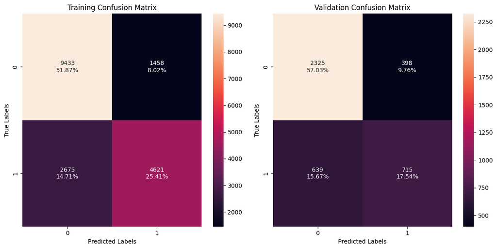

```python
# Plot confusion matrices for training, validation dataset
plot_confusion_matrices_v2(gradient_boost_classifier_tuned, X_train_over, y_train_over, X_val, y_val)
```

```python
# Compute performance metrics on training data set
gradient_boost_classifier_tuned_train_perf = model_performance_classification(gradient_boost_classifier_tuned, X_train_over, y_train_over)

# Compute performance metrics on validation data set
gradient_boost_classifier_tuned_val_perf = model_performance_classification(gradient_boost_classifier_tuned, X_val, y_val)

# print and compare model performances
gradient_boost_classifier_tuned_performance = model_performances(gradient_boost_classifier_tuned_train_perf, gradient_boost_classifier_tuned_val_perf)
gradient_boost_classifier_tuned_performance
```

|  |  | Accuracy | Recall | Precision | F1 |
| --- | --- | --- | --- | --- | --- |
| Training | 0 | 0.772750 | 0.633361 | 0.760158 | 0.690991 |
| Validation | 0 | 0.745646 | 0.528065 | 0.642408 | 0.579651 |

### **Model Observation Summary**

- There is a marginal increase in Precision compared to the non-hyperparam tuned model
- Other metrics are almost the same between the tuned-oversampled-model to the non-tuned-oversampled model
- Model is overfitting very mild as the diﬀerence between oversampled training data and validation data is minimal

### **Importances**

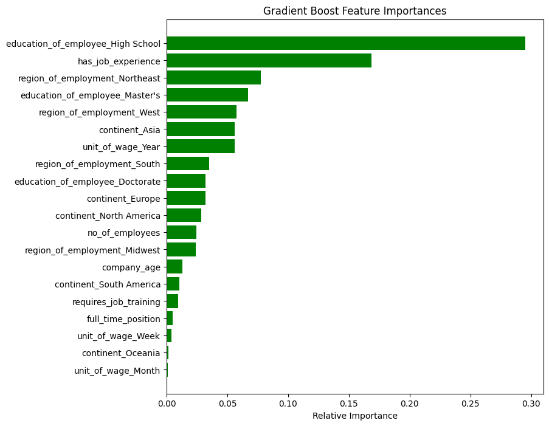

```python
# Compute and print the important features
gradient_boost_importances = gradient_boost_classifier_tuned.feature_importances_
gradient_boost_indices = np.argsort(gradient_boost_importances)
gradient_boost_feature_names = list(X.columns)

# Plot the feature importance
plt.figure(figsize=(8,8))
plt.title('Gradient Boost Feature Importances')
plt.barh(range(len(gradient_boost_indices)), gradient_boost_importances[gradient_boost_indices], color='green', align='center')
plt.yticks(range(len(gradient_boost_indices)), [gradient_boost_feature_names[i] for i in gradient_boost_indices])
plt.xlabel('Relative Importance')
plt.show()
```

### 3. **Tuning XG Boost (Oversampled)**

### **Hyper Parameters**

Following XGBoost hyper parameters will be used to tune to increase the model performance.

### **Cross Validation**

An automated search tool that tests multiple combinations of your XGBoost hyperparameters to find the best-performing set using cross-validation.

- *Precision and F1 Score* - The scoring metrics used to evaluate the model. Precision ensures that when the model approves or flags an application, it is usually correct. The F1 score balances precision and recall, making it ideal when dealing with rare outcomes.
- *n_jobs=-1* - A setting that tells your computer to use all available CPU cores simultaneously, speeding up the search process significantly.

```python
# Grid of hyper parameters to choose from GridSearchCV using XG Boost
xgb_parameters = {
    "n_estimators":[100, 150, 200],
    "learning_rate":[0.1,0.2],
    "subsample":[0.6,0.7,0.9,1],
    "gamma":[0,0.5,1],
    "colsample_bytree":[0.7,0.9,1],
    "colsample_bylevel":[0.7,0.9,1],
    "max_depth":[3,4,5]
}

# Precision and F1 scoring used to compare parameter combinations
xgb_scoring = {
    'precision': metrics.make_scorer(metrics.precision_score),
    'f1': metrics.make_scorer(metrics.f1_score)
}

# Create and run the grid search for all above combinations of hyper parameters
xgb_grid_search = GridSearchCV(xg_boost_classifier_oversampled, xgb_parameters, scoring=xgb_scoring, refit='f1', cv=5, n_jobs=-1)
xgb_grid_search = xgb_grid_search.fit(X_train_over, y_train_over)

# Set the clf to the best combination of parameters
xg_boost_classifier_tuned = xgb_grid_search.best_estimator_

# Fit the best algorithm to the data.
xg_boost_classifier_tuned.fit(X_train_over, y_train_over)
```

```
XGBClassifier(base_score=None, booster=None, callbacks=None,
              colsample_bylevel=0.9, colsample_bynode=None,
              colsample_bytree=0.7, device=None, early_stopping_rounds=None,
              enable_categorical=True, eval_metric='logloss',
              feature_types=None, feature_weights=None, gamma=0,
              grow_policy=None, importance_type=None,
              interaction_constraints=None, learning_rate=0.1, max_bin=None,
              max_cat_threshold=None, max_cat_to_onehot=None,
              max_delta_step=None, max_depth=4, max_leaves=None,
              min_child_weight=None, missing=nan, monotone_constraints=None,
              multi_strategy=None, n_estimators=150, n_jobs=None,
              num_parallel_tree=None, ...)
```

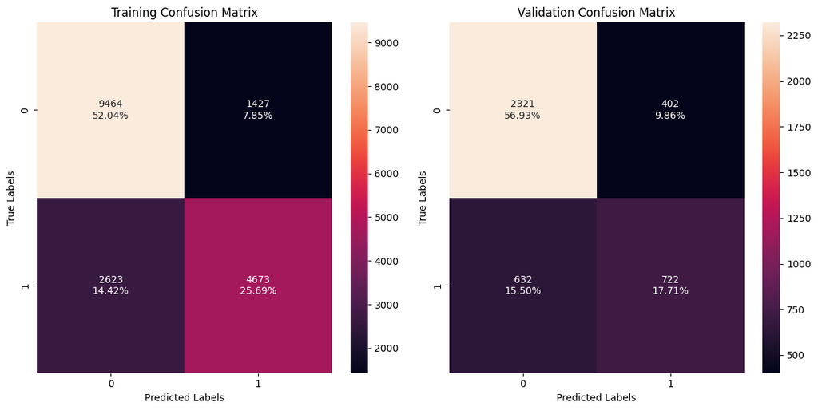

```python
# Plot confusion matrices for training and validation dataset
plot_confusion_matrices_v2(xg_boost_classifier_tuned, X_train_over, y_train_over, X_val, y_val)
```

```python
# Compute performance metrics on training data set
xg_boost_classifier_tuned_train_perf = model_performance_classification(xg_boost_classifier_tuned, X_train_over, y_train_over)

# Compute performance metrics on validation data
xg_boost_classifier_tuned_val_perf = model_performance_classification(xg_boost_classifier_tuned, X_val, y_val)

# Print and compare model performances
xg_boost_classifier_tuned_performance = model_performances(xg_boost_classifier_tuned_train_perf, xg_boost_classifier_tuned_val_perf)
xg_boost_classifier_tuned_performance
```

|  |  | Accuracy | Recall | Precision | F1 |
| --- | --- | --- | --- | --- | --- |
| Training | 0 | 0.777313 | 0.640488 | 0.766066 | 0.697671 |
| Validation | 0 | 0.746382 | 0.533235 | 0.642349 | 0.582728 |